# Project 03 — Meridian Media Mix Modeling

### Digital + TV spend with geo-level Bayesian inference and automated retraining

**Stack:** `meridian` · `tensorflow_probability` · `arviz` · `mlflow` · `dvc`  
**Audience:** B2C Retail · Intermediate | **Meridian version:** 1.6.1

## 📋 Executive Summary

> *For marketing directors, CMOs, and HR reviewers.*

### Business Question

What is the true ROI of each media channel once we account for saturation and carry-over effects — and how does performance vary across geographies?

### What We Found

[output not shown]

> **Effective ROAS** = Max ROAS × Hill(spend at average operating point).  
> **Max ROAS** = the return per dollar if the channel could reach full saturation (Hill → 1).

## ⚙️ Setup & Imports

```python
# !pip install google-meridian==1.6.1
# !pip install vl-convert-python
```

```python
# ── Core ──────────────────────────────────────────────────────────────────────
import sys
import os
sys.path.append(os.path.abspath('..'))
from config import *

import numpy as np
import pandas as pd
import scipy.stats as stats
import warnings
warnings.filterwarnings('ignore')

# ── Meridian ──────────────────────────────────────────────────────────────────
# meridian.model.model: the core Meridian MMM model class
from meridian import constants
from meridian.data import load
from meridian.data import test_utils
from meridian.data import input_data
from meridian.model import model
from meridian.model import spec
from meridian.model import prior_distribution
from meridian.analysis import optimizer
from meridian.analysis import analyzer
from meridian.analysis import visualizer
from meridian.analysis import summarizer
from meridian.analysis import formatter

# ── Bayesian diagnostics ───────────────────────────────────────────────────────
# arviz: the standard Python library for Bayesian diagnostics
#   az.summary(): R-hat, ESS, mean, sd, HDI in one table
#   az.rhat(): Gelman-Rubin convergence statistic per parameter
#   az.loo(): Leave-One-Out Cross Validation via PSIS
import arviz as az
import xarray as xr
import altair as alt

# ── Visualisation ─────────────────────────────────────────────────────────────
from IPython.display import Markdown, display
import plotly.graph_objects as go
import plotly.express as px
from plotly.subplots import make_subplots
import plotly.io as pio
pio.renderers.default = "png"
# ── MLOps ─────────────────────────────────────────────────────────────────────
try:
    import mlflow
    MLFLOW_AVAILABLE = True
    print('MLflow:', mlflow.__version__)
except ImportError:
    MLFLOW_AVAILABLE = False
    print('MLflow not installed — pip install mlflow')

RANDOM_SEED = 1111
np.random.seed(RANDOM_SEED)
print('ArviZ:', az.__version__)
print('Ready ✓')
```

[output not shown]

```
MLflow: 3.12.0
ArviZ: 0.19.0
Ready ✓
```

## 🧮 SQL / Data Layer

```
-- Weekly aggregated media spend and sales for MMM — geo-level
-- Produces one row per (week, geo) — the panel format Meridian's hierarchical model expects
SELECT
  date_trunc('week', event_date) AS week,
  geo_region,
  SUM(CASE WHEN channel='tv'          THEN spend END) AS tv_spend,
  SUM(CASE WHEN channel='paid_search' THEN spend END) AS search_spend,
  SUM(CASE WHEN channel='display'     THEN spend END) AS display_spend,
  SUM(CASE WHEN channel='social'      THEN spend END) AS social_spend,
  SUM(sales)     AS total_sales,
  AVG(price_idx) AS price_index
FROM media_attribution
WHERE event_date >= '2022-01-01'
GROUP BY 1, 2
ORDER BY 1, 2;
```

## 📦 Data Generation — Multi-Geo

104 weeks × 5 geographies of synthetic weekly media data with:

- Hill-function saturation injected per channel
- Geometric adstock decay (carry-over)
- Strong seasonality + geo-level ROAS multipliers
- Injected spend drift at week 80 to validate automated retraining
- **v2 bug fixes:** EC50_PARAMS (not SATURATION), pre-drift normalization, corrected social geo multiplier

```python
# ── Ground-truth parameters ────────────────────────────────────────────────────
CHANNELS_MMM = ['tv', 'paid_search', 'display', 'social']
GEOS         = ['north_east', 'south', 'mid_west', 'west', 'south_west']
N_WEEKS      = 104
N_GEOS       = len(GEOS)  # 5 geos: sufficient for geo-level partial pooling

# parameter within the Hill function used to model diminishing returns on advertising spend
EC50_PARAMS  = {'tv': 0.38, 'paid_search': 0.69, 'display': 0.56, 'social': 0.62}

# Geometric adstock decay rate λ per channel.
# Half-life: k_{1/2} = log(0.5)/log(λ).
# TV: k_{1/2} = log(0.5)/log(0.65) ≈ 1.6 weeks.
ADSTOCK_DECAY= {'tv': 0.65, 'paid_search': 0.20, 'display': 0.25, 'social': 0.30}

TRUE_ROAS    = {'tv': 3.4,  'paid_search': 3.8,  'display': 1.2,  'social': 2.6}

# North East: +18% above national average; South: -18% below.
# These multiplicatively scale the base_sales for each geo.
GEO_BASELINE = {
    'north_east': 1.18,
    'south':      0.82,
    'mid_west':   0.97,
    'west':       1.12,
    'south_west': 0.91,
}

GEO_ROAS_MULTIPLIER = {
    'north_east': {'tv': 1.10, 'paid_search': 1.05, 'display': 0.95, 'social': 1.00},
    'south':      {'tv': 0.90, 'paid_search': 0.85, 'display': 1.10, 'social': 1.05},
    'mid_west':   {'tv': 1.00, 'paid_search': 1.00, 'display': 1.00, 'social': 1.00},
    'west':       {'tv': 0.95, 'paid_search': 1.15, 'display': 0.90, 'social': 1.10},
    'south_west': {'tv': 1.05, 'paid_search': 0.95, 'display': 1.05, 'social': 0.85},
}

# ── Verify partial pooling constraint holds for all channels ──────────────────
for ch in CHANNELS_MMM:
    total = sum(GEO_ROAS_MULTIPLIER[g][ch] for g in GEOS)
    assert abs(total - 5.0) < 1e-9, f'Partial pooling violated for {ch}: sum={total}'
assert abs(sum(GEO_BASELINE.values()) - 5.0) < 1e-9, 'GEO_BASELINE partial pooling violated'
print('Partial pooling constraint verified ✓ — all geo multipliers sum to 5.00')

def hill_function(x, ec=0.5, slope=2.0):
    return (x**slope) / (ec**slope + x**slope)  # output range: [0, 1]

def apply_adstock(spend, decay):
    adstocked    = np.zeros_like(spend, dtype=float)  # pre-allocate: same shape as input
    adstocked[0] = spend[0]                           # t=0: no previous period, A_0 = X_0
    for t in range(1, len(spend)):                    # causal: no look-ahead
        adstocked[t] = spend[t] + decay * adstocked[t-1]
    return adstocked

rng        = np.random.default_rng(RANDOM_SEED)  # isolated generator
weeks      = np.arange(N_WEEKS)                  # 0, 1, 2, ..., 103
# 2π/52: angular frequency — one full cycle per 52 weeks.
seasonality= 1 + 0.3 * np.sin(2 * np.pi * weeks / 52)  # range: [0.70, 1.30]
week_dates = pd.date_range('2022-01-03', periods=N_WEEKS, freq='W')

# ── Generate national spend (broadcast across geos with geo-specific noise) ───
national_spend = {}
for ch in CHANNELS_MMM:
    base = {'tv': 50000, 'paid_search': 30000, 'display': 25000, 'social': 20000}[ch]
    national_spend[ch] = np.abs(rng.normal(base, base * 0.2, N_WEEKS))
    national_spend[ch][80:] *= 1.4   # +40% spend drift at week 80: structural break

# ── Build geo-level panel ──────────────────────────────────────────────────────
records = []
for geo in GEOS:
    # Geo-specific base sales: scaled by geo baseline multiplier
    base_sales = 500_000 * GEO_BASELINE[geo]
    sales = base_sales * seasonality.copy()   # element-wise multiply: seasonal baseline

    geo_spend = {}
    for ch in CHANNELS_MMM:
        geo_alloc = rng.uniform(0.15, 0.25)          # fraction of national budget
        noise     = rng.normal(1.0, 0.05, N_WEEKS)   # ±5% weekly execution noise
        geo_spend[ch] = national_spend[ch] * geo_alloc * noise

        # ── Revenue generation: adstock → normalize → Hill → ROAS × spend ────
        adstocked = apply_adstock(geo_spend[ch], ADSTOCK_DECAY[ch])  # carry-over
        # normalize by pre-drift mean spend (weeks 0-79)
        ref_spend = adstocked[:80].mean() if adstocked[:80].mean() > 0 else adstocked.mean()
        saturated = hill_function(adstocked / ref_spend, ec=EC50_PARAMS[ch])  # [0, ~1+]
        saturated = np.clip(saturated, 0, 1)  # clip: adstocked can exceed ref post-drift
        roas_adj  = TRUE_ROAS[ch] * GEO_ROAS_MULTIPLIER[geo][ch]     # geo-adjusted max ROAS
        sales    += roas_adj * geo_spend[ch] * saturated             # channel contribution

    # Add observation noise: 5% std deviation on base_sales
    sales += rng.normal(0, base_sales * 0.05, N_WEEKS)

    # Build records: one dict per (geo, week)
    for t in range(N_WEEKS):
        row = {'week': week_dates[t], 'geo': geo, 'sales': sales[t],
               'seasonality': seasonality[t]}
        for ch in CHANNELS_MMM:
            row[f'{ch}_spend'] = geo_spend[ch][t]
        records.append(row)

df_panel = pd.DataFrame(records)
df_panel = df_panel.sort_values(['geo', 'week']).reset_index(drop=True)

df_national = df_panel.groupby('week').agg(
    sales=('sales', 'sum'),
    **{f'{ch}_spend': (f'{ch}_spend', 'sum') for ch in CHANNELS_MMM}
).reset_index()

# ── Report actual effective ROAS (correct labeling) ───────────────────────────
# This is what the model should recover
print('\n=== Ground-truth effective ROAS (what model should recover) ===')
rows = []
for ch in CHANNELS_MMM:
    geo_rows  = df_panel[df_panel['geo'] == 'mid_west'].sort_values('week')
    spend_arr = geo_rows[f'{ch}_spend'].values
    ads       = apply_adstock(spend_arr, ADSTOCK_DECAY[ch])
    ref       = ads[:80].mean()
    sat       = np.clip(hill_function(ads / ref, ec=EC50_PARAMS[ch]), 0, 1)
    eff_roas  = TRUE_ROAS[ch] * sat.mean()
    rows.append({
        'channel':        ch,
        'true_roas':      TRUE_ROAS[ch],
        'effective_roas': eff_roas,
        'saturation':     sat.mean(),
        'discount':       1 - (eff_roas / TRUE_ROAS[ch]),
    })

roas_df = pd.DataFrame(rows).set_index('channel')

display(
    roas_df.style
        .format({
            'true_roas':      '{:.1f}x',
            'effective_roas': '{:.2f}x',
            'saturation':     '{:.1%}',
            'discount':       '{:.1%}',
        })
)

print(f'\nPanel shape: {df_panel.shape} | Geos: {N_GEOS} | Weeks: {N_WEEKS}')
print(f'National sales range: ${df_national.sales.min():,.0f} – ${df_national.sales.max():,.0f}')
df_panel.head(10)
```

```
Partial pooling constraint verified ✓ — all geo multipliers sum to 5.00

=== Ground-truth effective ROAS (what model should recover) ===
```

| channel | true_roas | effective_roas | saturation | discount |
| --- | --- | --- | --- | --- |
| tv | 3.4x | 3.00x | 88.1% | 11.9% |
| paid_search | 3.8x | 2.64x | 69.4% | 30.6% |
| display | 1.2x | 0.94x | 77.9% | 22.1% |
| social | 2.6x | 1.92x | 73.7% | 26.3% |

```
Panel shape: (520, 8) | Geos: 5 | Weeks: 104
National sales range: $2,021,911 – $3,590,733
```

|  | week | geo | sales | seasonality | tv_spend | paid_search_spend | display_spend | social_spend |
| --- | --- | --- | --- | --- | --- | --- | --- | --- |
| 0 | 2022-01-09 | mid_west | 552905.990401 | 1.000000 | 12689.973052 | 6066.991149 | 6064.812760 | 3492.748893 |
| 1 | 2022-01-16 | mid_west | 609615.874871 | 1.036161 | 12215.068825 | 7976.009697 | 4025.079088 | 3185.610361 |
| 2 | 2022-01-23 | mid_west | 568101.935447 | 1.071795 | 7321.176511 | 3733.072405 | 5564.226619 | 3680.212874 |
| 3 | 2022-01-30 | mid_west | 593104.945126 | 1.106381 | 10665.461919 | 6409.757993 | 5234.345037 | 5179.408668 |
| 4 | 2022-02-06 | mid_west | 587638.264681 | 1.139417 | 11371.004601 | 6671.348869 | 3792.154868 | 5116.415874 |
| 5 | 2022-02-13 | mid_west | 636382.912449 | 1.170419 | 10732.382443 | 7610.788898 | 5780.421798 | 4243.888210 |
| 6 | 2022-02-20 | mid_west | 662888.622378 | 1.198937 | 12855.581998 | 8238.203365 | 3950.749353 | 5394.873112 |
| 7 | 2022-02-27 | mid_west | 621904.935184 | 1.224553 | 11351.475911 | 7133.649657 | 3937.164973 | 6213.464878 |
| 8 | 2022-03-06 | mid_west | 661658.725585 | 1.246895 | 8228.543969 | 7556.035611 | 3548.546766 | 4028.470503 |
| 9 | 2022-03-13 | mid_west | 719357.562830 | 1.265637 | 12758.663219 | 9084.552580 | 4714.159452 | 3390.996073 |

## 🗂️ Meridian InputData Construction

We build the `InputData` object using `meridian.data.input_data` — the v1.6.1 entry point. All tensors are wrapped as **`xr.DataArray`** objects with exact Meridian dim-name constants.

```python
# ── Build tensors in Meridian's expected shape ────────────────────────────────
# KPI (sales): (n_geos, n_time)
# Media spend: (n_geos, n_time, n_channels)
n_g, n_t, n_ch = N_GEOS, N_WEEKS, len(CHANNELS_MMM)  # 5, 104, 4

# KPI tensor: (n_geos, n_time) — shape (5, 104)
kpi_tensor = np.zeros((n_g, n_t), dtype=np.float32)
for g, geo in enumerate(GEOS):
    kpi_tensor[g] = df_panel[df_panel.geo == geo].sort_values('week')['sales'].values

media_tensor = np.zeros((n_g, n_t, n_ch), dtype=np.float32)
for g, geo in enumerate(GEOS):
    geo_df = df_panel[df_panel.geo == geo].sort_values('week')
    for c, ch in enumerate(CHANNELS_MMM):
        media_tensor[g, :, c] = geo_df[f'{ch}_spend'].values

season_tensor = np.tile(seasonality, (n_g, 1))[:, :, np.newaxis].astype(np.float32)

# ── Coordinates ────────────────────────────────────────────────────────────────
coord_geo   = list(GEOS)
coord_time  = [str(d.date()) for d in week_dates]  # ISO date strings: '2022-01-03'
coord_media = list(CHANNELS_MMM)

# ── Wrap numpy arrays as xr.DataArrays ────────────────────────────────────────
# Every DataArray must satisfy two rules:
#   2. .name must equal the matching constants string (Meridian validates this
#      in __post_init__ and raises ValueError if the name is wrong)

kpi_da = xr.DataArray(
    kpi_tensor,                                        # (5, 104) float32 array
    dims=[constants.GEO, constants.TIME],              # dim names: 'geo', 'time'
    coords={constants.GEO: coord_geo,                  # attaches string labels to each axis
            constants.TIME: coord_time},               # so Meridian outputs are human-readable
    name=constants.KPI,                                # must equal 'kpi' — validated in __post_init__
)

# media uses MEDIA_TIME (not TIME) because media can have more time periods than
# Here n_media_times == n_times (no lag buffer), which is valid but not recommended
# for channels with long carryover effects.
media_da = xr.DataArray(
    media_tensor,                                      # (5, 104, 4) float32 array
    dims=[constants.GEO,
          constants.MEDIA_TIME,                        # 'media_time' — separate dim from 'time'
          constants.MEDIA_CHANNEL],                    # 'media_channel'
    coords={constants.GEO:           coord_geo,
            constants.MEDIA_TIME:    coord_time,       # same dates as KPI here (no lag buffer)
            constants.MEDIA_CHANNEL: coord_media},
    name=constants.MEDIA,                              # must equal 'media'
)

# media_spend uses TIME (not MEDIA_TIME) — spend is aligned to the KPI window.
media_spend_da = xr.DataArray(
    media_tensor,                                      # (5, 104, 4) float32 — same values as media here
    dims=[constants.GEO,
          constants.TIME,                              # 'time' — aligned to KPI window
          constants.MEDIA_CHANNEL],
    coords={constants.GEO:           coord_geo,
            constants.TIME:          coord_time,
            constants.MEDIA_CHANNEL: coord_media},
    name=constants.MEDIA_SPEND,                        # must equal 'media_spend'
)

# and list their names in the CONTROL_VARIABLE coord.
controls_da = xr.DataArray(
    season_tensor,                                     # (5, 104, 1) float32 array
    dims=[constants.GEO,
          constants.TIME,
          constants.CONTROL_VARIABLE],                 # 'control_variable'
    coords={constants.GEO:              coord_geo,
            constants.TIME:             coord_time,
            constants.CONTROL_VARIABLE: ['seasonality']},
    name=constants.CONTROLS,                           # must equal 'controls'
)

# on KPI * revenue_per_kpi so results are in revenue terms.
revenue_per_kpi_da = xr.DataArray(
    np.ones((n_g, n_t), dtype=np.float32),             # (5, 104) float32 — all 1.0
    dims=[constants.GEO, constants.TIME],
    coords={constants.GEO:  coord_geo,
            constants.TIME: coord_time},
    name=constants.REVENUE_PER_KPI,                    # must equal 'revenue_per_kpi'
)

# population: (n_geos,) — mandatory field with no default value.
population_da = xr.DataArray(
    np.ones(n_g, dtype=np.float32),                    # (5,) float32 — equal weight per geo
    dims=[constants.GEO],
    coords={constants.GEO: coord_geo},
    name=constants.POPULATION,                         # must equal 'population'
)

# ── Build Meridian InputData ───────────────────────────────────────────────────
input_data = input_data.InputData(
    kpi             = kpi_da,
    kpi_type        = constants.NON_REVENUE,  # 'non_revenue': KPI is sales units, not revenue
    population      = population_da,          # mandatory — no default — scales KPI by geo size
    media           = media_da,               # volume/impressions tensor
    media_spend     = media_spend_da,         # spend tensor (same values as volume here)
    controls        = controls_da,            # seasonality as a control variable
    revenue_per_kpi = revenue_per_kpi_da,     # 1.0 per cell: KPI is already in revenue units
)

print('InputData created ✓')
print(f'  KPI shape:      {input_data.kpi.shape}')      # expect (5, 104)
print(f'  Media shape:    {input_data.media.shape}')    # expect (5, 104, 4)
print(f'  Controls shape: {input_data.controls.shape}') # expect (5, 104, 1)
print(f'  Geos:           {input_data.geo.values}')     # .geo is a property — singular, not .geos
print(f'  Channels:       {input_data.media_channel.values}')  # .media_channel — singular
```

```
InputData created ✓
  KPI shape:      (5, 104)
  Media shape:    (5, 104, 4)
  Controls shape: (5, 104, 1)
  Geos:           ['north_east' 'south' 'mid_west' 'west' 'south_west']
  Channels:       ['tv' 'paid_search' 'display' 'social']
```

## 🧱 Model Specification — Priors & Spec

```python
import tensorflow_probability as tfp
import tensorflow as tf

# ── Prior distributions ────────────────────────────────────────────────────────
# Priors encode domain knowledge before seeing any data.
priors = prior_distribution.PriorDistribution(
    roi_m   = tfp.distributions.LogNormal(
                  loc=tf.cast(tf.math.log(2.0), tf.float32),
                  scale=tf.constant(0.8, tf.float32)),

    roi_rf  = tfp.distributions.LogNormal(
                  loc=tf.cast(tf.math.log(2.0), tf.float32),
                  scale=tf.constant(0.8, tf.float32)),

    ec_m    = tfp.distributions.Beta(
                  concentration1=tf.constant(2.0, tf.float32),
                  concentration0=tf.constant(3.0, tf.float32)),

    slope_m = tfp.distributions.HalfNormal(scale=tf.constant(1.0, tf.float32)),

    alpha_m = tfp.distributions.Beta(
                  concentration1=tf.constant(2.0, tf.float32),
                  concentration0=tf.constant(2.0, tf.float32)),

    sigma   = tfp.distributions.HalfNormal(scale=tf.constant(0.5, tf.float32)),

    # tau_g_excl_baseline: geo-level deviation standard deviation
    tau_g_excl_baseline = tfp.distributions.HalfNormal(scale=tf.constant(0.5, tf.float32)),
)

# ── Model spec ────────────────────────────────────────────────────────────────
mmm_spec = spec.ModelSpec(
    prior                 = priors,
    max_lag               = 8,               # consider up to 8 weeks of adstock carry-over
                                             # TV half-life ≈ 1.6 weeks → 5 half-lives = 8 weeks
    paid_media_prior_type = constants.ROI,   # parameterize by ROI not contribution
    knots                 = 26,
)
```

```
2026-05-30 20:48:31.911345: E external/local_xla/xla/stream_executor/cuda/cuda_platform.cc:51] failed call to cuInit: INTERNAL: CUDA error: Failed call to cuInit: UNKNOWN ERROR (303)
```

## 🔬 Meridian Model — Fit (MCMC)

We use **No-U-Turn Sampling (NUTS)** via Meridian's TensorFlow Probability backend. 2 chains × 500 adapt + 500 burnin + 1000 draws. Runtime: ~10–20 min on CPU.

```python
# ── Initialise Meridian MMM ────────────────────────────────────────────────────
# model.Meridian is the main model class.
mmm = model.Meridian(
    input_data = input_data,
    model_spec = mmm_spec,
)
print('Meridian model initialised ✓')

# ── Sample posterior via NUTS ─────────────────────────────────────────────────
#   n_chains=2 used here for portfolio demo to reduce runtime.
#   These samples are DISCARDED. Not included in the posterior.
#   In Meridian, n_adapt and n_burnin are separate phases.
# n_keep: the number of RETAINED posterior samples per chain.
mmm.sample_posterior(
    n_chains = 2,
    n_adapt  = 500,
    n_burnin = 500,
    n_keep   = 1000,
    seed     = RANDOM_SEED,
)
print('Posterior sampling complete ✓')
print(f'  Chains × draws: {mmm.inference_data.posterior.dims}')
```

[output not shown]

```
Meridian model initialised ✓
```

```
2026-05-30 20:49:51.284218: I tensorflow/compiler/mlir/tensorflow/utils/dump_mlir_util.cc:269] disabling MLIR crash reproducer, set env var `MLIR_CRASH_REPRODUCER_DIRECTORY` to enable.
2026-05-30 20:49:55.078216: W tensorflow/compiler/tf2xla/kernels/assert_op.cc:39] Ignoring Assert operator mcmc_retry_init/assert_equal_1/Assert/AssertGuard/Assert
```

```
Posterior sampling complete ✓
  Chains × draws: FrozenMappingWarningOnValuesAccess({'chain': 2, 'draw': 1000, 'media_channel': 4, 'geo': 5, 'control_variable': 1, 'knots': 26, 'time': 104})
```

```
2026-05-30 20:56:19.011831: E tensorflow/core/util/util.cc:131] oneDNN supports DT_BOOL only on platforms with AVX-512. Falling back to the default Eigen-based implementation if present.
```

## 🩺 Bayesian Diagnostics — ArviZ

We assess:

- **R̂ (Gelman-Rubin)** — chain convergence; target < 1.01
- **ESS (Effective Sample Size)** — sampling efficiency; target > 400
- **Trace plots** — visual chain mixing
- **Posterior predictive check** — Meridian's ModelFit class

```python
# ── Convert Meridian posterior to ArviZ InferenceData ─────────────────────────
#   posterior: MCMC samples from p(θ | data)
#   posterior_predictive: samples from p(y_new | θ, data)
idata = mmm.inference_data

summary = az.summary(idata, var_names=['roi_m', 'ec_m', 'slope_m', 'alpha_m', 'sigma'])
print('=== ArviZ Posterior Summary ===')
display(summary)
```

```
=== ArviZ Posterior Summary ===
```

|  | mean | sd | hdi_3% | hdi_97% | mcse_mean | mcse_sd | ess_bulk | ess_tail | r_hat |
| --- | --- | --- | --- | --- | --- | --- | --- | --- | --- |
| roi_m[tv] | 4.244 | 2.246 | 0.427 | 8.273 | 0.097 | 0.068 | 490.0 | 830.0 | 1.00 |
| roi_m[paid_search] | 10.518 | 4.519 | 3.707 | 19.997 | 0.213 | 0.153 | 484.0 | 643.0 | 1.01 |
| roi_m[display] | 3.189 | 2.621 | 0.217 | 7.846 | 0.096 | 0.076 | 969.0 | 1024.0 | 1.00 |
| roi_m[social] | 2.450 | 2.007 | 0.185 | 6.105 | 0.059 | 0.042 | 1416.0 | 1192.0 | 1.00 |
| ec_m[tv] | 0.535 | 0.191 | 0.161 | 0.863 | 0.005 | 0.004 | 1339.0 | 1134.0 | 1.00 |
| ec_m[paid_search] | 0.630 | 0.162 | 0.342 | 0.916 | 0.005 | 0.003 | 1244.0 | 1414.0 | 1.00 |
| ec_m[display] | 0.437 | 0.202 | 0.085 | 0.795 | 0.004 | 0.003 | 2097.0 | 1179.0 | 1.00 |
| ec_m[social] | 0.394 | 0.194 | 0.047 | 0.738 | 0.004 | 0.003 | 2799.0 | 1352.0 | 1.00 |
| slope_m[tv] | 0.905 | 0.430 | 0.142 | 1.725 | 0.012 | 0.008 | 1208.0 | 649.0 | 1.00 |
| slope_m[paid_search] | 1.231 | 0.484 | 0.455 | 2.149 | 0.017 | 0.012 | 764.0 | 1256.0 | 1.01 |
| slope_m[display] | 0.850 | 0.594 | 0.000 | 1.882 | 0.014 | 0.010 | 1481.0 | 904.0 | 1.00 |
| slope_m[social] | 0.789 | 0.611 | 0.003 | 1.915 | 0.012 | 0.009 | 2439.0 | 1127.0 | 1.00 |
| alpha_m[tv] | 0.413 | 0.176 | 0.057 | 0.693 | 0.004 | 0.003 | 1608.0 | 1132.0 | 1.00 |
| alpha_m[paid_search] | 0.209 | 0.108 | 0.025 | 0.400 | 0.003 | 0.002 | 1625.0 | 1105.0 | 1.00 |
| alpha_m[display] | 0.424 | 0.234 | 0.041 | 0.837 | 0.005 | 0.004 | 2109.0 | 1275.0 | 1.00 |
| alpha_m[social] | 0.496 | 0.215 | 0.126 | 0.894 | 0.004 | 0.003 | 2262.0 | 1243.0 | 1.00 |
| sigma | 0.202 | 0.006 | 0.191 | 0.214 | 0.000 | 0.000 | 2041.0 | 1477.0 | 1.00 |

```python
# ── R-hat convergence check ───────────────────────────────────────────────────
rhat = az.rhat(idata, var_names=['roi_m', 'ec_m', 'slope_m', 'alpha_m'])

print('=== R-hat (Gelman-Rubin) — target < 1.01 ===')
for var in ['roi_m', 'ec_m', 'slope_m', 'alpha_m']:
    vals   = rhat[var].values.flatten()  # one R-hat per parameter dimension (channel)
    status = '✓' if (vals < 1.01).all() else '⚠️'
    print(f'  {var:<8} max={vals.max():.4f}  mean={vals.mean():.4f}  {status}')

# ── ESS check ─────────────────────────────────────────────────────────────────
# ESS < 100: very poor — unreliable percentile estimates.
# ESS > 400: good — credible intervals are reliable.
ess = az.ess(idata, var_names=['roi_m', 'ec_m', 'slope_m', 'alpha_m'])

ess_rows = []
for var in ['roi_m', 'ec_m', 'slope_m', 'alpha_m']:
    vals = ess[var].values.flatten()
    ess_rows.append({
        'variable': var,
        'min':  vals.min(),
        'mean': vals.mean(),
        'max':  vals.max(),
        'status': '✓ OK' if (vals > 400).all() else '⚠️ Low'
    })

ess_df = pd.DataFrame(ess_rows).set_index('variable')

display(
    ess_df.style
        .format({'min': '{:.0f}', 'mean': '{:.0f}', 'max': '{:.0f}'})
        .background_gradient(subset=['min', 'mean', 'max'], cmap='gray_r', vmin=0, vmax=8000)
        .applymap(lambda v: f'color: {C_GREEN}; font-weight: bold' if '✓' in v
                            else f'color: {C_ORANGE}; font-weight: bold', subset=['status'])
        .set_caption('Effective Sample Size — target > 400')
)
```

```
=== R-hat (Gelman-Rubin) — target < 1.01 ===
  roi_m    max=1.0088  mean=1.0027  ✓
  ec_m     max=1.0015  mean=1.0007  ✓
  slope_m  max=1.0075  mean=1.0025  ✓
  alpha_m  max=1.0017  mean=1.0010  ✓
```

Effective Sample Size — target > 400

| variable | min | mean | max | status |
| --- | --- | --- | --- | --- |
| roi_m | 484 | 840 | 1416 | ✓ OK |
| ec_m | 1244 | 1870 | 2799 | ✓ OK |
| slope_m | 764 | 1473 | 2439 | ✓ OK |
| alpha_m | 1608 | 1901 | 2262 | ✓ OK |

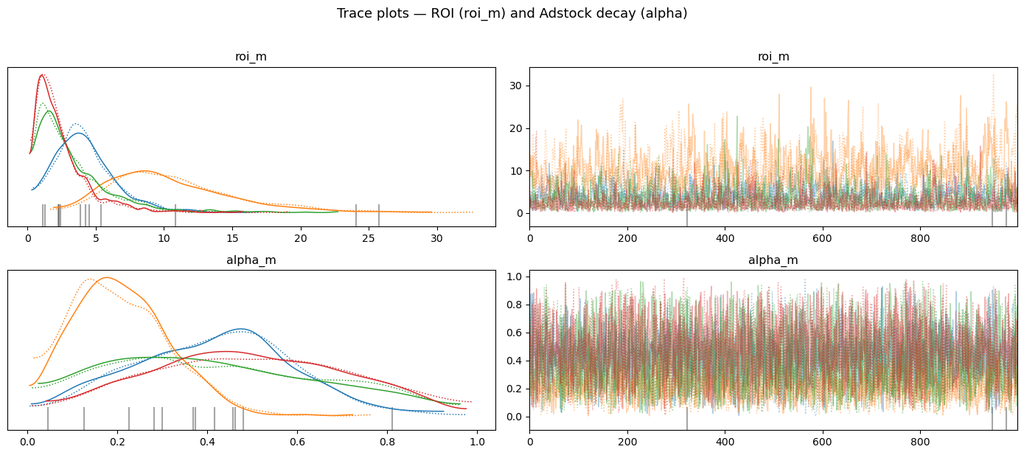

```python
# ── Trace plots — roi_m and alpha ─────────────────────────────────────────────
# compact=True: one row per parameter combining all channels
az.plot_trace(
    idata,
    var_names=['roi_m', 'alpha_m'],
    compact=True,
    figsize=(14, 6),
)
import matplotlib.pyplot as plt
plt.suptitle('Trace plots — ROI (roi_m) and Adstock decay (alpha)', y=1.02, fontsize=13)
plt.tight_layout()
plt.show()
```

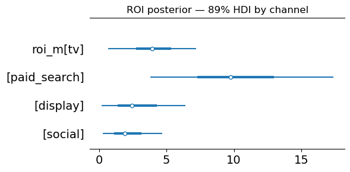

```python
# ── Forest plot — ROI posterior by channel ────────────────────────────────────
# hdi_prob=0.89: shows the 89% Highest Density Interval (HDI).
# 89% is the highest prime number below 90%. More importantly,
az.plot_forest(
    idata,
    var_names=['roi_m'],
    combined=True,     # combine all chains into one distribution
    hdi_prob=0.89,     # 89% HDI
    figsize=(6, 3),
)
plt.title('ROI posterior — 89% HDI by channel', fontsize=12)
plt.tight_layout()
plt.show()
```

```python
from meridian.analysis import analyzer, visualizer

# ── Convergence check ─────────────────────────────────────────────────────────
# media channels for roi_m are summarised in one box).
model_diagnostics = visualizer.ModelDiagnostics(mmm)
model_diagnostics.plot_rhat_boxplot()

# ── Posterior Predictive Check ────────────────────────────────────────────────
model_fit = visualizer.ModelFit(mmm)
model_fit.plot_model_fit()

# ── Quantitative fit metrics ──────────────────────────────────────────────────
model_diagnostics.predictive_accuracy_table()
```

|  | metric | geo_granularity | value |
| --- | --- | --- | --- |
| 0 | R_Squared | geo | 0.962761 |
| 1 | R_Squared | national | 0.991523 |
| 2 | MAPE | geo | 0.036093 |
| 3 | MAPE | national | 0.013629 |
| 4 | wMAPE | geo | 0.034578 |
| 5 | wMAPE | national | 0.013019 |

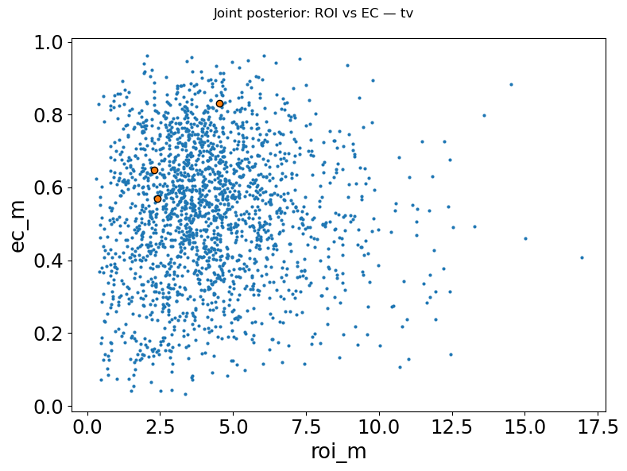

```python
# ── Pair plot — ec vs roi_m (first channel) ───────────────────────────────────
az.plot_pair(
    idata,
    var_names=['roi_m', 'ec_m'],
    coords={'media_channel': CHANNELS_MMM[0]},   # focus on first channel (tv)
    divergences=True,    # mark divergent transitions in red
    figsize=(8, 6),
)
plt.suptitle(f'Joint posterior: ROI vs EC — {CHANNELS_MMM[0]}', fontsize=12)
plt.tight_layout()
plt.show()
```

```
=== R-hat and ESS diagnostics ===
```

|  | mcse_mean | mcse_sd | ess_bulk | ess_tail | r_hat |
| --- | --- | --- | --- | --- | --- |
| roi_m[tv] | 0.097 | 0.068 | 490.0 | 830.0 | 1.00 |
| roi_m[paid_search] | 0.213 | 0.153 | 484.0 | 643.0 | 1.01 |
| roi_m[display] | 0.096 | 0.076 | 969.0 | 1024.0 | 1.00 |
| roi_m[social] | 0.059 | 0.042 | 1416.0 | 1192.0 | 1.00 |
| alpha_m[tv] | 0.004 | 0.003 | 1608.0 | 1132.0 | 1.00 |
| alpha_m[paid_search] | 0.003 | 0.002 | 1625.0 | 1105.0 | 1.00 |
| alpha_m[display] | 0.005 | 0.004 | 2109.0 | 1275.0 | 1.00 |
| alpha_m[social] | 0.004 | 0.003 | 2262.0 | 1243.0 | 1.00 |
| ec_m[tv] | 0.005 | 0.004 | 1339.0 | 1134.0 | 1.00 |
| ec_m[paid_search] | 0.005 | 0.003 | 1244.0 | 1414.0 | 1.00 |
| ec_m[display] | 0.004 | 0.003 | 2097.0 | 1179.0 | 1.00 |
| ec_m[social] | 0.004 | 0.003 | 2799.0 | 1352.0 | 1.00 |
| slope_m[tv] | 0.012 | 0.008 | 1208.0 | 649.0 | 1.00 |
| slope_m[paid_search] | 0.017 | 0.012 | 764.0 | 1256.0 | 1.01 |
| slope_m[display] | 0.014 | 0.010 | 1481.0 | 904.0 | 1.00 |
| slope_m[social] | 0.012 | 0.009 | 2439.0 | 1127.0 | 1.00 |
| sigma | 0.000 | 0.000 | 2041.0 | 1477.0 | 1.00 |

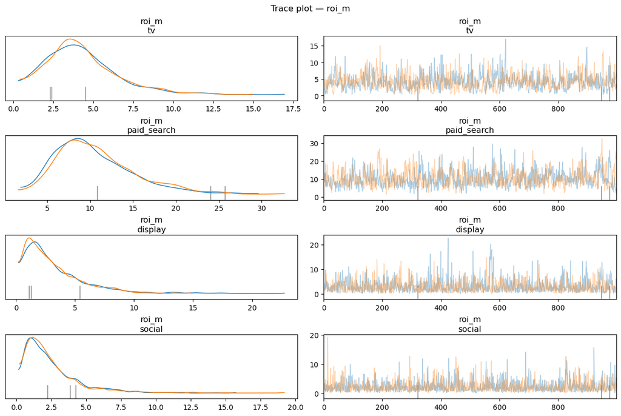

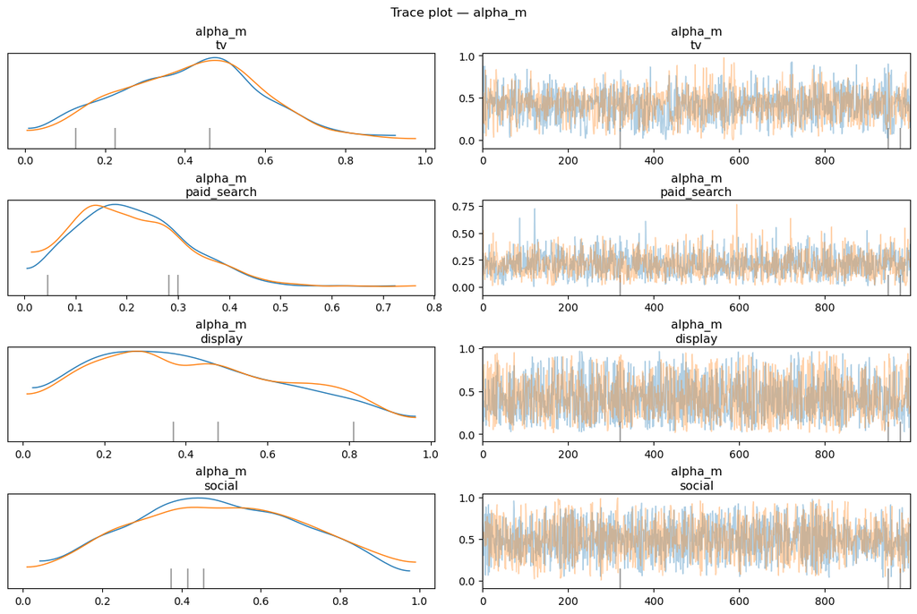

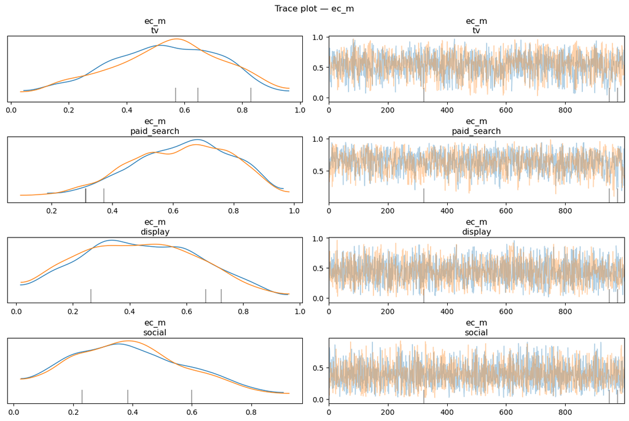

```
Max R-hat across all parameters: 1.0153  →  ✓ converged
```

```python
# ── MCMC convergence diagnostics ─────────────────────────────────────────────
# so az.plot_energy / az.bfmi are not available. Use R-hat and ESS instead —

# R-hat (Gelman-Rubin potential scale reduction factor)
# Compares variance between chains to variance within chains.
rhat_summary = az.summary(idata, var_names=['roi_m', 'alpha_m', 'ec_m', 'slope_m', 'sigma'],
                           kind='diagnostics')
print('=== R-hat and ESS diagnostics ===')
display(rhat_summary)

for param in ['roi_m', 'alpha_m', 'ec_m']:
    az.plot_trace(
        idata,
        var_names=[param],
        compact=False,
        backend_kwargs={'constrained_layout': True},
    )
    plt.suptitle(f'Trace plot — {param}', fontsize=12)
    plt.show()

# Meridian's ModelDiagnostics uses this same value internally.
mmm_analyzer = analyzer.Analyzer(mmm)
rhat_vals = mmm_analyzer.get_rhat()
max_rhat   = max(float(v.numpy().max()) for v in rhat_vals.values())
status     = '✓ converged' if max_rhat < 1.2 else '⚠️  not converged — run longer chains'
print(f'\nMax R-hat across all parameters: {max_rhat:.4f}  →  {status}')
```

```python
# ── Out-of-sample predictive accuracy ────────────────────────────────────────
# LOO-CV (az.loo) is not available for Meridian — it requires pointwise
#
# Meridian's equivalent is Analyzer.predictive_accuracy():
#
# Interpretation mirrors LOO-CV intent:
#   R²  > 0.80 : good — model explains most KPI variance
mmm_analyzer = analyzer.Analyzer(mmm)
fit_metrics   = mmm_analyzer.predictive_accuracy()  # returns xr.Dataset, not DataFrame
print('=== Predictive accuracy (in-sample) ===')
display(fit_metrics.to_dataframe())        # .to_dataframe() first, then .to_string()

# ── How to get a proper train/test split on the next fit ─────────────────────
#
# mmm_spec = spec.ModelSpec(
#     prior                 = priors,
#     max_lag               = 8,
#     paid_media_prior_type = constants.ROI,
#     knots                 = 26,
# )
```

```
=== Predictive accuracy (in-sample) ===
```

| metric | geo_granularity | value |
| --- | --- | --- |
| R_Squared | geo | 0.962761 |
|  | national | 0.991523 |
| MAPE | geo | 0.036093 |
|  | national | 0.013629 |
| wMAPE | geo | 0.034578 |
|  | national | 0.013019 |

```python
# ── Divergences summary ───────────────────────────────────────────────────────
n_divergences = int(idata.sample_stats.diverging.values.sum())  # total across all chains
total_samples = int(idata.sample_stats.diverging.values.size)   # n_chains × n_keep
div_pct = n_divergences / total_samples * 100
status  = '✓' if div_pct < 1.0 else '⚠️ re-parameterize'
print(f'Divergences: {n_divergences} / {total_samples} ({div_pct:.2f}%)  {status}')
```

```
Divergences: 3 / 2000 (0.15%)  ✓
```

## 📊 Meridian Analyzer — Contributions & ROAS

```python
# ── Run Meridian analyzer ─────────────────────────────────────────────────────
mmm_analyzer = analyzer.Analyzer(mmm)

roi_tensor   = mmm_analyzer.roi()                              # (chains, draws, channels)
roi_mean     = roi_tensor.numpy().mean(axis=(0, 1))            # (n_channels,)
roi_p10      = np.percentile(roi_tensor.numpy(), 10, axis=(0,1))  # 10th percentile
roi_p90      = np.percentile(roi_tensor.numpy(), 90, axis=(0,1))  # 90th percentile — 80% CI

inc_tensor   = mmm_analyzer.incremental_outcome()              # (chains, draws, channels)
inc_mean     = inc_tensor.numpy().mean(axis=(0, 1))            # posterior mean per channel

channel_names = list(input_data.media_channel.values)         # labels from InputData

# ── Summary table ─────────────────────────────────────────────────────────────
results_df = pd.DataFrame({
    'channel'            : channel_names,
    'incremental_outcome': inc_mean,
    'roi_mean'           : roi_mean,
    'roi_p10'            : roi_p10,           # lower bound of 80% credible interval
    'roi_p90'            : roi_p90,           # upper bound of 80% credible interval
})
results_df['pct_of_contribution'] = (
    results_df['incremental_outcome'] / results_df['incremental_outcome'].sum()
)
print('=== Channel contributions and ROI summary ===')
display(results_df)

roi_np   = roi_tensor.numpy()
roi_prob = (roi_np >= 1.0).mean(axis=(0, 1))

roi_prob_df = pd.DataFrame({
    'channel': channel_names,
    'P(ROI > 1.0)': roi_prob,
    'status': ['✓ Profitable' if p >= 0.8 else '⚠️ Uncertain' for p in roi_prob]
}).set_index('channel').sort_values('P(ROI > 1.0)', ascending=False)

def color_status(v):
    if '✓' in v: return f'color: {C_GREEN}; font-weight: bold'
    return f'color: {C_ORANGE}; font-weight: bold'

display(
    roi_prob_df.style
        .format({'P(ROI > 1.0)': '{:.1%}'})
        .applymap(color_status, subset=['status'])
        .set_caption('P(ROI > 1.0) per channel — probability each channel is profitable')
)
```

```
=== Channel contributions and ROI summary ===
```

|  | channel | incremental_outcome | roi_mean | roi_p10 | roi_p90 | pct_of_contribution |
| --- | --- | --- | --- | --- | --- | --- |
| 0 | tv | 24282430.0 | 4.243720 | 1.664572 | 7.135138 | 0.314792 |
| 1 | paid_search | 38122416.0 | 10.517653 | 5.483857 | 16.660172 | 0.494211 |
| 2 | display | 9146205.0 | 3.189409 | 0.785195 | 6.625437 | 0.118569 |
| 3 | social | 5586933.0 | 2.449596 | 0.667128 | 4.795790 | 0.072428 |

P(ROI > 1.0) per channel — probability each channel is profitable

| channel | P(ROI > 1.0) | status |
| --- | --- | --- |
| paid_search | 100.0% | ✓ Profitable |
| tv | 96.0% | ✓ Profitable |
| display | 83.7% | ✓ Profitable |
| social | 78.6% | ⚠️ Uncertain |

```python
# ── Geo-level ROI breakdown ───────────────────────────────────────────────────
geo_roi_tensor = mmm_analyzer.roi(aggregate_geos=False)   # (chains, draws, geos, channels)
geo_roi_mean   = geo_roi_tensor.numpy().mean(axis=(0, 1)) # (n_geos, n_channels)

channel_names = list(input_data.media_channel.values)
geo_names     = list(input_data.geo.values)

geo_roi_df = pd.DataFrame(
    geo_roi_mean,
    index=geo_names,
    columns=channel_names,
)
geo_roi_df.index.name = 'geo'

print('=== ROI by Geo × Channel (posterior mean) ===')
display(geo_roi_df)
```

```
=== ROI by Geo × Channel (posterior mean) ===
```

| geo | tv | paid_search | display | social |
| --- | --- | --- | --- | --- |
| north_east | 9.960032 | 15.160039 | 4.986845 | 3.457182 |
| south | 1.613857 | 7.714207 | 2.118768 | 1.667285 |
| mid_west | 2.746639 | 9.614275 | 2.837956 | 1.993422 |
| west | 3.612997 | 9.393354 | 3.985248 | 3.067975 |
| south_west | 2.575951 | 9.507092 | 2.298286 | 2.146068 |

```python
# ── Sample prior — required before summary_metrics() ─────────────────────────
# to compute prior vs posterior shift for each channel.
# This cannot be skipped — sample_prior() must be called before summary_metrics().
mmm.sample_prior(500)
print('Prior sampling complete ✓')

# ── Meridian model results summary ───────────────────────────────────────────
# Summarizer.output_model_fit_summary() does not exist.
# to disk — it does not return a printable object.
#
# This is the primary business-readable output of Meridian.
mmm_analyzer = analyzer.Analyzer(mmm)
summary_ds   = mmm_analyzer.summary_metrics(use_kpi=True)

summary_df = summary_ds.to_dataframe().reset_index()

display(
    summary_df.style
        .format({
            'roi':           '{:.2f}x',
            'effectiveness': '{:.2f}',
            'mroi':          '{:.2f}',
            'cpik':          '{:.4f}',
            'spend':         '${:,.0f}',
            'pct_of_spend':  '{:.1%}',
        }, na_rep='—')
        .bar(subset=['roi'],           vmin=0, color=C_GREEN+'80')
        .bar(subset=['effectiveness'], vmin=0, color=C_SKY+'80')
        .set_caption('Meridian Model Results Summary — KPI units')
)
```

```
Prior sampling complete ✓
```

Meridian Model Results Summary — KPI units

|  | channel | metric | distribution | impressions | pct_of_impressions | spend | pct_of_spend | cpm | incremental_outcome | pct_of_contribution | roi | effectiveness | mroi | cpik |
| --- | --- | --- | --- | --- | --- | --- | --- | --- | --- | --- | --- | --- | --- | --- |
| 0 | tv | mean | prior | 5721974.000000 | 39.475452 | $5,721,974 | 3947.5% | 1000.000000 | 16281433.000000 | 4.526797 | 2.85x | 2.85 | 0.56 | 0.6677 |
| 1 | tv | mean | posterior | 5721974.000000 | 39.475452 | $5,721,974 | 3947.5% | 1000.000000 | 24282430.000000 | 8.245617 | 4.24x | 4.24 | 1.22 | 0.3390 |
| 2 | tv | median | prior | 5721974.000000 | 39.475452 | $5,721,974 | 3947.5% | 1000.000000 | 11250222.000000 | 3.127947 | 1.97x | 1.97 | 0.34 | 0.5086 |
| 3 | tv | median | posterior | 5721974.000000 | 39.475452 | $5,721,974 | 3947.5% | 1000.000000 | 22508508.000000 | 7.643246 | 3.93x | 3.93 | 1.12 | 0.2542 |
| 4 | tv | ci_lo | prior | 5721974.000000 | 39.475452 | $5,721,974 | 3947.5% | 1000.000000 | 3336741.250000 | 0.927728 | 0.58x | 0.58 | 0.03 | 0.1323 |
| 5 | tv | ci_lo | posterior | 5721974.000000 | 39.475452 | $5,721,974 | 3947.5% | 1000.000000 | 6485585.000000 | 2.202319 | 1.13x | 1.13 | 0.18 | 0.1168 |
| 6 | tv | ci_hi | prior | 5721974.000000 | 39.475452 | $5,721,974 | 3947.5% | 1000.000000 | 43256828.000000 | 12.026878 | 7.56x | 7.56 | 1.79 | 1.7148 |
| 7 | tv | ci_hi | posterior | 5721974.000000 | 39.475452 | $5,721,974 | 3947.5% | 1000.000000 | 48971676.000000 | 16.629383 | 8.56x | 8.56 | 2.56 | 0.8823 |
| 8 | paid_search | mean | prior | 3624605.750000 | 25.005875 | $3,624,606 | 2500.6% | 1000.000000 | 10215340.000000 | 2.840217 | 2.82x | 2.82 | 0.55 | 0.6352 |
| 9 | paid_search | mean | posterior | 3624605.750000 | 25.005875 | $3,624,606 | 2500.6% | 1000.000000 | 38122408.000000 | 12.945264 | 10.52x | 10.52 | 3.99 | 0.1154 |
| 10 | paid_search | median | prior | 3624605.750000 | 25.005875 | $3,624,606 | 2500.6% | 1000.000000 | 7396295.000000 | 2.056423 | 2.04x | 2.04 | 0.33 | 0.4901 |
| 11 | paid_search | median | posterior | 3624605.750000 | 25.005875 | $3,624,606 | 2500.6% | 1000.000000 | 35303976.000000 | 11.988222 | 9.74x | 9.74 | 3.93 | 0.1027 |
| 12 | paid_search | ci_lo | prior | 3624605.750000 | 25.005875 | $3,624,606 | 2500.6% | 1000.000000 | 2173076.750000 | 0.604190 | 0.60x | 0.60 | 0.03 | 0.1267 |
| 13 | paid_search | ci_lo | posterior | 3624605.750000 | 25.005875 | $3,624,606 | 2500.6% | 1000.000000 | 16686576.000000 | 5.666284 | 4.60x | 4.60 | 2.02 | 0.0514 |
| 14 | paid_search | ci_hi | prior | 3624605.750000 | 25.005875 | $3,624,606 | 2500.6% | 1000.000000 | 28605420.000000 | 7.953285 | 7.89x | 7.89 | 1.69 | 1.6680 |
| 15 | paid_search | ci_hi | posterior | 3624605.750000 | 25.005875 | $3,624,606 | 2500.6% | 1000.000000 | 70551952.000000 | 23.957426 | 19.46x | 19.46 | 6.21 | 0.2172 |
| 16 | display | mean | prior | 2867681.250000 | 19.783909 | $2,867,681 | 1978.4% | 1000.000000 | 8222898.000000 | 2.286249 | 2.87x | 2.87 | 0.59 | 0.6588 |
| 17 | display | mean | posterior | 2867681.250000 | 19.783909 | $2,867,681 | 1978.4% | 1000.000000 | 9146205.000000 | 3.105788 | 3.19x | 3.19 | 0.74 | 0.5996 |
| 18 | display | median | prior | 2867681.250000 | 19.783909 | $2,867,681 | 1978.4% | 1000.000000 | 5676707.000000 | 1.578319 | 1.98x | 1.98 | 0.33 | 0.5052 |
| 19 | display | median | posterior | 2867681.250000 | 19.783909 | $2,867,681 | 1978.4% | 1000.000000 | 7007854.500000 | 2.379667 | 2.44x | 2.44 | 0.48 | 0.4092 |
| 20 | display | ci_lo | prior | 2867681.250000 | 19.783909 | $2,867,681 | 1978.4% | 1000.000000 | 1741859.750000 | 0.484297 | 0.61x | 0.61 | 0.03 | 0.1377 |
| 21 | display | ci_lo | posterior | 2867681.250000 | 19.783909 | $2,867,681 | 1978.4% | 1000.000000 | 1668338.125000 | 0.566520 | 0.58x | 0.58 | 0.05 | 0.1215 |
| 22 | display | ci_hi | prior | 2867681.250000 | 19.783909 | $2,867,681 | 1978.4% | 1000.000000 | 20824426.000000 | 5.789903 | 7.26x | 7.26 | 1.78 | 1.6463 |
| 23 | display | ci_hi | posterior | 2867681.250000 | 19.783909 | $2,867,681 | 1978.4% | 1000.000000 | 23594534.000000 | 8.012029 | 8.23x | 8.23 | 2.26 | 1.7189 |
| 24 | social | mean | prior | 2280756.500000 | 15.734762 | $2,280,756 | 1573.5% | 1000.000000 | 6006980.000000 | 1.670146 | 2.63x | 2.63 | 0.56 | 0.6967 |
| 25 | social | mean | posterior | 2280756.500000 | 15.734762 | $2,280,756 | 1573.5% | 1000.000000 | 5586933.000000 | 1.897159 | 2.45x | 2.45 | 0.45 | 0.7285 |
| 26 | social | median | prior | 2280756.500000 | 15.734762 | $2,280,756 | 1573.5% | 1000.000000 | 4371882.500000 | 1.215533 | 1.92x | 1.92 | 0.33 | 0.5217 |
| 27 | social | median | posterior | 2280756.500000 | 15.734762 | $2,280,756 | 1573.5% | 1000.000000 | 4338840.000000 | 1.473346 | 1.90x | 1.90 | 0.29 | 0.5257 |
| 28 | social | ci_lo | prior | 2280756.500000 | 15.734762 | $2,280,756 | 1573.5% | 1000.000000 | 1206950.375000 | 0.335573 | 0.53x | 0.53 | 0.03 | 0.1434 |
| 29 | social | ci_lo | posterior | 2280756.500000 | 15.734762 | $2,280,756 | 1573.5% | 1000.000000 | 1216215.875000 | 0.412992 | 0.53x | 0.53 | 0.03 | 0.1554 |
| 30 | social | ci_hi | prior | 2280756.500000 | 15.734762 | $2,280,756 | 1573.5% | 1000.000000 | 15904460.000000 | 4.421984 | 6.97x | 6.97 | 1.75 | 1.8897 |
| 31 | social | ci_hi | posterior | 2280756.500000 | 15.734762 | $2,280,756 | 1573.5% | 1000.000000 | 14673859.000000 | 4.982823 | 6.43x | 6.43 | 1.45 | 1.8753 |
| 32 | All Channels | mean | prior | 14495018.000000 | 100.000000 | $14,495,018 | 10000.0% | 1000.000000 | 40726656.000000 | 11.323403 | 2.81x | — | — | 0.4394 |
| 33 | All Channels | mean | posterior | 14495018.000000 | 100.000000 | $14,495,018 | 10000.0% | 1000.000000 | 77138064.000000 | 26.193810 | 5.32x | — | — | 0.1994 |
| 34 | All Channels | median | prior | 14495018.000000 | 100.000000 | $14,495,018 | 10000.0% | 1000.000000 | 37274104.000000 | 10.363476 | 2.57x | — | — | 0.3889 |
| 35 | All Channels | median | posterior | 14495018.000000 | 100.000000 | $14,495,018 | 10000.0% | 1000.000000 | 74875584.000000 | 25.425606 | 5.17x | — | — | 0.1936 |
| 36 | All Channels | ci_lo | prior | 14495018.000000 | 100.000000 | $14,495,018 | 10000.0% | 1000.000000 | 17073488.000000 | 4.747014 | 1.18x | — | — | 0.1838 |
| 37 | All Channels | ci_lo | posterior | 14495018.000000 | 100.000000 | $14,495,018 | 10000.0% | 1000.000000 | 50524632.000000 | 17.156721 | 3.49x | — | — | 0.1292 |
| 38 | All Channels | ci_hi | prior | 14495018.000000 | 100.000000 | $14,495,018 | 10000.0% | 1000.000000 | 78850080.000000 | 21.923019 | 5.44x | — | — | 0.8490 |
| 39 | All Channels | ci_hi | posterior | 14495018.000000 | 100.000000 | $14,495,018 | 10000.0% | 1000.000000 | 112157552.000000 | 38.085499 | 7.74x | — | — | 0.2869 |

## 📊 Visual Story — Meridian Built-in Visualizations

```python
# ── Meridian visualizer: response curves ──────────────────────────────────────
# Shows the Hill saturation curve for each channel.
media_effects = visualizer.MediaEffects(mmm)
fig = media_effects.plot_response_curves()
fig.show()
```

[interactive chart not shown]

```python
fig = media_effects.plot_adstock_decay()  # Adstock decay per channel
fig.show()
```

[interactive chart not shown]

```python
# ── Visualizer classes — each handles one domain ─────────────────────────────
#   ModelFit         : predicted vs observed KPI

model_fit     = visualizer.ModelFit(mmm)
media_summary = visualizer.MediaSummary(mmm)

# ── Predicted vs observed KPI ─────────────────────────────────────────────────
fig = model_fit.plot_model_fit()
fig.show()
```

[interactive chart not shown]

```python
# ── ROI bar chart per channel ─────────────────────────────────────────────────
# High bar + narrow CI = confident high performer.
fig = media_summary.plot_roi_bar_chart()
fig.show()
```

[interactive chart not shown]

```python
# ── Contribution pie chart ────────────────────────────────────────────────────
fig = media_summary.plot_contribution_pie_chart()
fig.show()
```

[interactive chart not shown]

## 🎨 Custom Visualizations — Extended Analysis

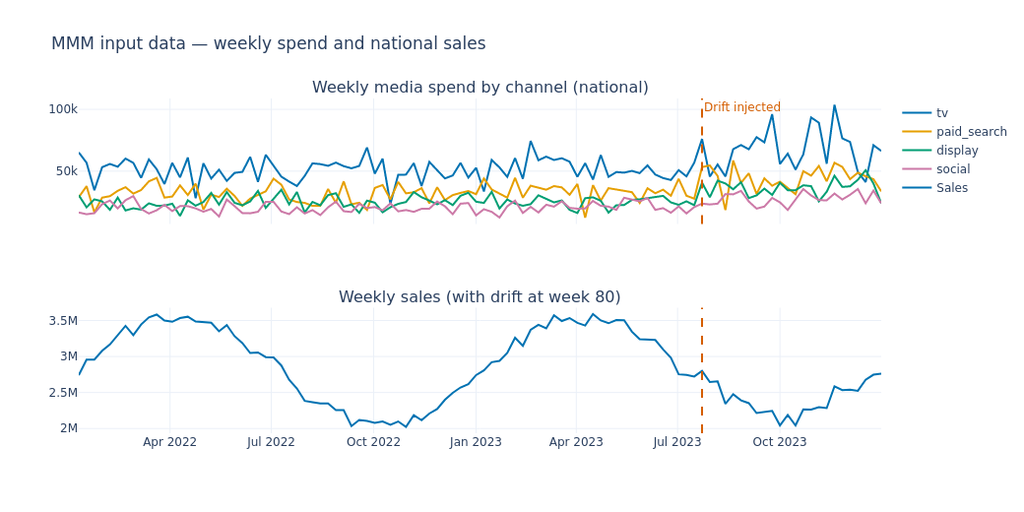

```python
# ── Fig 1: National spend vs sales time series ────────────────────────────────
# shared_xaxes=True: zooming/panning on one panel syncs both —
fig = make_subplots(rows=2, cols=1, shared_xaxes=True,
    subplot_titles=['Weekly media spend by channel (national)', 'Weekly sales (with drift at week 80)'])
for i, ch in enumerate(CHANNELS_MMM):
    fig.add_trace(go.Scatter(
        x=df_national.week, y=df_national[f'{ch}_spend'],
        name=ch, line=dict(color=PALETTE_CATEGORICAL[i])), row=1, col=1)
fig.add_trace(go.Scatter(
    x=df_national.week, y=df_national.sales,
    name='Sales', line=dict(color=C_BLUE, width=2)), row=2, col=1)

drift_x = str(week_dates[80].date())
fig.add_vline(x=drift_x, line_dash='dash', line_color=C_VERMILLION)
fig.add_annotation(
    x=drift_x, y=1, yref='paper',   # yref='paper': y=1 is top of the figure
    text='Drift injected',
    showarrow=False,
    font=dict(color=C_VERMILLION),
    xanchor='left',
)

fig.update_layout(height=520, width=1040, template=PLOTLY_TEMPLATE,
    title='MMM input data — weekly spend and national sales',
    font=dict(family=FONT_FAMILY, size=12))
fig.show()
```

```
Effective saturation at average spend (Hill output at x=1.0):
```

Hill function — EC50 and current saturation per channel

| channel | EC50 | saturation |
| --- | --- | --- |
| tv | 0.38 | 87% |
| display | 0.56 | 76% |
| social | 0.62 | 72% |
| paid_search | 0.69 | 68% |

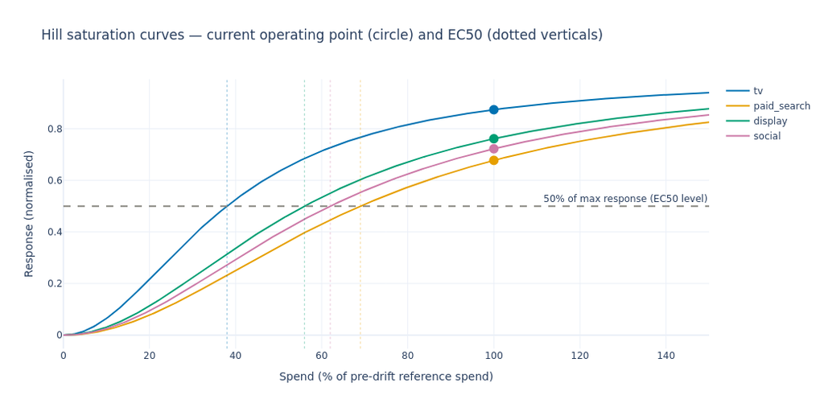

```python
# ── Fig 2: Hill saturation curves per channel ─────────────────────────────────
fig2 = go.Figure()
x_norm = np.linspace(0, 1.5, 300)  # extend to 150% of ref spend to show full curve shape

for i, ch in enumerate(CHANNELS_MMM):
    ec = EC50_PARAMS[ch]                           # EC50 directly — no longer 1 - value
    y  = hill_function(x_norm, ec=ec)              # full response curve

    fig2.add_trace(go.Scatter(
        x=x_norm * 100, y=y, name=ch,
        line=dict(color=PALETTE_CATEGORICAL[i], width=2)))

    op_x = 1.0                                     # average spend = 100% of ref spend
    op_y = hill_function(op_x, ec=ec)              # response at average operating point
    eff_sat_pct = op_y * 100                       # saturation % at average spend

    fig2.add_trace(go.Scatter(
        x=[op_x * 100], y=[op_y], mode='markers',
        marker=dict(color=PALETTE_CATEGORICAL[i], size=12, symbol='circle'),
        showlegend=False,
        hovertemplate=f'{ch}: EC50={ec:.2f}, saturation at avg spend={eff_sat_pct:.0f}%<extra></extra>'))

for i, ch in enumerate(CHANNELS_MMM):
    fig2.add_vline(
        x=EC50_PARAMS[ch] * 100,
        line_dash='dot', line_color=PALETTE_CATEGORICAL[i],
        line_width=1, opacity=0.4,
    )

fig2.add_hline(y=0.5, line_dash='dash', line_color=C_GRAY,
               annotation_text='50% of max response (EC50 level)')

fig2.update_layout(height=420, width=840, template=PLOTLY_TEMPLATE,
    title='Hill saturation curves — current operating point (circle) and EC50 (dotted verticals)',
    xaxis_title='Spend (% of pre-drift reference spend)', yaxis_title='Response (normalised)',
    font=dict(family=FONT_FAMILY, size=12))

# Print effective saturation at average spend for each channel
print('Effective saturation at average spend (Hill output at x=1.0):')
sat_rows = []
for ch in CHANNELS_MMM:
    ec  = EC50_PARAMS[ch]
    sat = hill_function(1.0, ec=ec)
    sat_rows.append({'channel': ch, 'EC50': ec, 'saturation': sat})

sat_df = pd.DataFrame(sat_rows).set_index('channel').sort_values('saturation', ascending=False)

display(
    sat_df.style
        .format({'EC50': '{:.2f}', 'saturation': '{:.0%}'})
        .set_caption('Hill function — EC50 and current saturation per channel')
)
fig2.update_layout(height=520, width=1040, template=PLOTLY_TEMPLATE)
fig2.show()
```

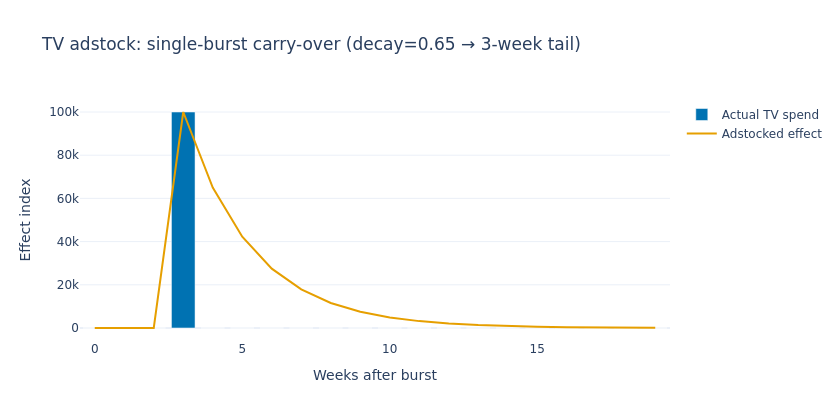

```python
# ── Fig 3: Adstock carry-over illustration for TV ─────────────────────────────
tv_spend_sample    = np.zeros(20)   # 20-week horizon
tv_spend_sample[3] = 100_000        # single burst in week 3
tv_adstocked       = apply_adstock(tv_spend_sample, ADSTOCK_DECAY['tv'])

fig3 = go.Figure()
# Bar chart for actual spend: discrete weekly decisions
fig3.add_trace(go.Bar(x=list(range(20)), y=tv_spend_sample,
    name='Actual TV spend', marker_color=C_BLUE))
# Line chart for adstocked effect: continuous decaying tail
fig3.add_trace(go.Scatter(x=list(range(20)), y=tv_adstocked,
    name='Adstocked effect', line=dict(color=C_ORANGE, width=2)))
fig3.update_layout(height=420, width=840, template=PLOTLY_TEMPLATE,
    title='TV adstock: single-burst carry-over (decay=0.65 → 3-week tail)',
    xaxis_title='Weeks after burst', yaxis_title='Effect index',
    font=dict(family=FONT_FAMILY, size=12))
fig3.show()
```

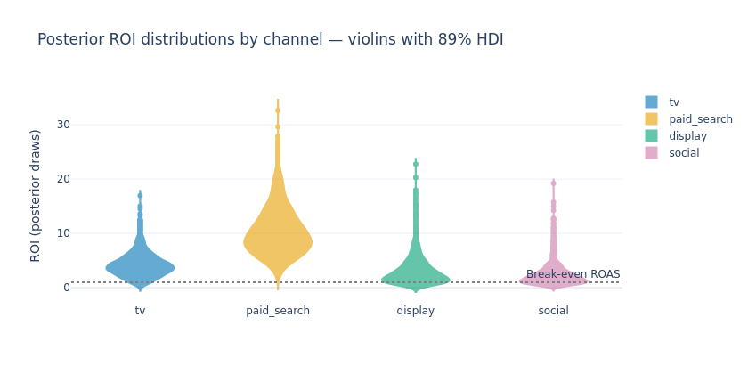

```python
# ── Fig 4: Posterior ROI distributions (violin) ───────────────────────────────
# with a specific shape, median, and spread.
roi_samples = idata.posterior['roi_m'].values  # shape: (n_chains, n_draws, n_channels)
roi_flat    = roi_samples.reshape(-1, len(CHANNELS_MMM))

fig4 = go.Figure()
for i, ch in enumerate(CHANNELS_MMM):
    fig4.add_trace(go.Violin(
        y=roi_flat[:, i],  # column i = all posterior draws for channel i
        name=ch,
        box_visible=True,       # show IQR box inside violin
        meanline_visible=True,  # show posterior mean as horizontal line
        line_color=PALETTE_CATEGORICAL[i],
        fillcolor=PALETTE_CATEGORICAL[i], opacity=0.6))

fig4.add_hline(y=1.0, line_dash='dot', line_color='gray',
    annotation_text='Break-even ROAS')
fig4.update_layout(height=420, width=840, template=PLOTLY_TEMPLATE,
    title='Posterior ROI distributions by channel — violins with 89% HDI',
    yaxis_title='ROI (posterior draws)',
    font=dict(family=FONT_FAMILY, size=12))
fig4.show()
```

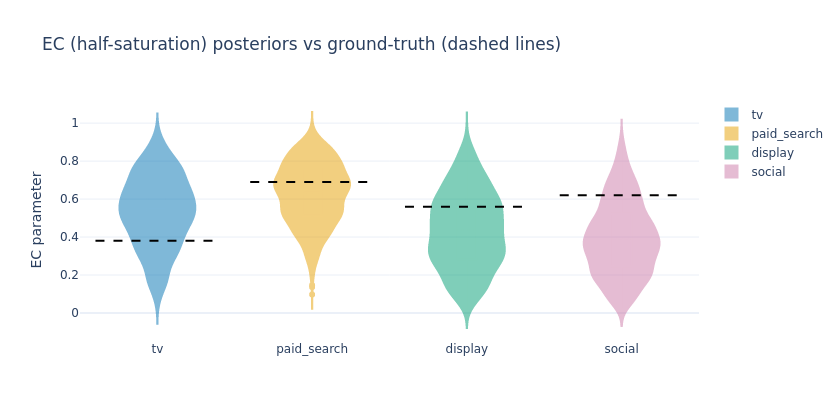

```python
# ── Fig 5: EC (saturation) posteriors vs ground truth ────────────────────────
ec_samples = idata.posterior['ec_m'].values.reshape(-1, len(CHANNELS_MMM))
SATURATION = {ch: 1 - EC50_PARAMS[ch] for ch in CHANNELS_MMM}

fig5 = go.Figure()
for i, ch in enumerate(CHANNELS_MMM):
    fig5.add_trace(go.Violin(
        y=ec_samples[:, i], name=ch,
        box_visible=True, meanline_visible=True,
        line_color=PALETTE_CATEGORICAL[i],
        fillcolor=PALETTE_CATEGORICAL[i], opacity=0.5))
    # Ground-truth EC for this channel: 1 - SATURATION[ch]
    # A dashed black line shows what the model should recover
    true_ec = 1 - SATURATION[ch]
    fig5.add_shape(type='line',
        x0=i-0.4, x1=i+0.4, y0=true_ec, y1=true_ec,
        line=dict(color='black', dash='dash', width=2))

fig5.update_layout(height=420, width=840, template=PLOTLY_TEMPLATE,
    title='EC (half-saturation) posteriors vs ground-truth (dashed lines)',
    yaxis_title='EC parameter',
    font=dict(family=FONT_FAMILY, size=12))
fig5.show()
```

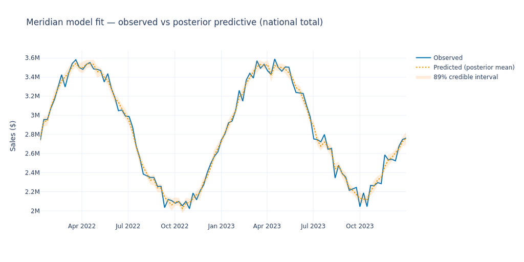

```python
# ── Fig 6: Actual vs predicted (national) ───────────────────────────────────
# Meridian does not populate idata.posterior_predictive — use
# as a tensor of shape (chains, draws, geos, time).
mmm_analyzer  = analyzer.Analyzer(mmm)

pred_tensor   = mmm_analyzer.expected_outcome(
    use_posterior      = True,
    aggregate_geos     = False,   # (chains, draws, geos, time)
    aggregate_times    = False,
    use_kpi            = True,
)
pred_np       = pred_tensor.numpy()                          # (chains, draws, geos, time)
pred_national = pred_np.sum(axis=2)                          # sum geos → (chains, draws, time)
pred_mean     = pred_national.mean(axis=(0, 1))              # posterior mean → (time,)
obs_national  = kpi_tensor.sum(axis=0)                       # observed national total → (time,)

ppc_lo = np.quantile(pred_national, 0.055, axis=(0, 1))      # lower bound (time,)
ppc_hi = np.quantile(pred_national, 0.945, axis=(0, 1))      # upper bound (time,)

fig6 = go.Figure()
fig6.add_trace(go.Scatter(x=week_dates, y=obs_national,
    name='Observed', line=dict(color=C_BLUE, width=2)))
fig6.add_trace(go.Scatter(x=week_dates, y=pred_mean,
    name='Predicted (posterior mean)', line=dict(color=C_ORANGE, width=2, dash='dot')))

fig6.add_trace(go.Scatter(
    x=np.concatenate([week_dates, week_dates[::-1]]),
    y=np.concatenate([ppc_hi, ppc_lo[::-1]]),
    fill='toself', fillcolor='rgba(255,127,14,0.15)',
    line=dict(color='rgba(255,255,255,0)'),
    name='89% credible interval', showlegend=True))

fig6.update_layout(height=520, width=1040, template=PLOTLY_TEMPLATE,
    title='Meridian model fit — observed vs posterior predictive (national total)',
    yaxis_title='Sales ($)', font=dict(family=FONT_FAMILY, size=12))

fig6.show()
```

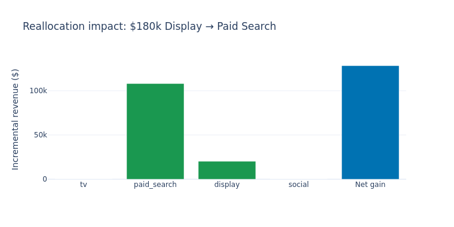

```
Projected net incremental revenue: $128,305
```

```python
# ── Fig 7: Budget reallocation waterfall ─────────────────────────────────────
# Proposed: shift $180k from Display to Paid Search
REALLOC = {'display': -180_000, 'paid_search': +180_000, 'tv': 0, 'social': 0}

def marginal_roas(ch, delta):
    sat  = SATURATION[ch]
    ec   = 1 - sat
    base = hill_function(sat, ec=ec)  # Hill value at current saturation
    new  = hill_function(sat + delta / df_national[f'{ch}_spend'].mean(), ec=ec)  # Hill value at new saturation
    return TRUE_ROAS[ch] * (new - base) * df_national[f'{ch}_spend'].mean()

incremental = {ch: marginal_roas(ch, REALLOC[ch]) for ch in CHANNELS_MMM}
total_gain  = sum(incremental.values())

bar_x  = list(incremental.keys()) + ['Net gain']
bar_y  = list(incremental.values()) + [total_gain]
bar_c  = [C_NEGATIVE if v < 0 else C_POSITIVE for v in list(incremental.values())] + [C_BLUE]

fig7 = go.Figure(go.Bar(x=bar_x, y=bar_y, marker_color=bar_c))
fig7.update_layout(height=380, width=760, template=PLOTLY_TEMPLATE,
    title='Reallocation impact: $180k Display → Paid Search',
    yaxis_title='Incremental revenue ($)',
    font=dict(family=FONT_FAMILY, size=12))

fig7.show()

print(f'Projected net incremental revenue: ${total_gain:,.0f}')
```

## 🎯 Meridian Budget Optimizer

```python
# ── Run Meridian budget optimizer ─────────────────────────────────────────────
# that maximizes EXPECTED revenue under posterior uncertainty.
#   Point-estimate optimization: maximize f(μ_ROI)
budget_optimizer = optimizer.BudgetOptimizer(mmm)

# Current spend per channel: total across the full period
current_national_spend = {
    ch: df_national[f'{ch}_spend'].sum() for ch in CHANNELS_MMM
}
total_budget = sum(current_national_spend.values())

# Optimize within ±30% of current spend per channel.
# spend_constraint_lower / spend_constraint_upper: fractional deviation from
# current spend — 0.3 means the channel can go down/up by 30%.
# spend_bounds does not exist — the correct kwargs are:
#   spend_constraint_lower = 0.3  → floor = 70% of current spend
#   spend_constraint_upper = 0.3  → cap  = 130% of current spend
optimization_result = budget_optimizer.optimize(
    budget                 = total_budget,
    spend_constraint_lower = 0.3,   # all channels: floor at 70% of current spend
    spend_constraint_upper = 0.3,   # all channels: cap  at 130% of current spend
    use_kpi                = True,  # optimise KPI units, not revenue
)
```

Budget Optimization — how it works

| Concept | Point-estimate | **Posterior-aware (this model)** |
| --- | --- | --- |
| What is optimized | μ_ROI point estimate | Full posterior distribution of ROI |
| Uncertainty handling | Ignored | Hedges against wide credible intervals |
| Result | Single budget vector | Distribution over optimal allocations |
| Risk | Over-allocates to uncertain channels | Conservatively allocates to uncertain channels |

The optimizer solves: **maximize E[KPI(x)]** subject to Σxᵢ = budget and xᵢ ∈ [floor, cap]

```python
budget_optimizer = optimizer.BudgetOptimizer(mmm)

current_national_spend = {
    ch: df_national[f'{ch}_spend'].sum() for ch in CHANNELS_MMM
}
total_budget = sum(current_national_spend.values())

# Display current spend going into optimizer
spend_df = pd.DataFrame.from_dict(
    current_national_spend, orient='index', columns=['current_spend']
)
spend_df['% of budget'] = spend_df['current_spend'] / total_budget
spend_df['floor (−30%)'] = spend_df['current_spend'] * 0.7
spend_df['cap (+30%)']   = spend_df['current_spend'] * 1.3

display(
    spend_df.style
        .format({'current_spend': '${:,.0f}', '% of budget': '{:.1%}',
                 'floor (−30%)': '${:,.0f}', 'cap (+30%)': '${:,.0f}'})
        .set_caption(f'Current spend by channel — total budget ${total_budget:,.0f}')
)

optimization_result = budget_optimizer.optimize(
    budget                 = total_budget,
    spend_constraint_lower = 0.3,
    spend_constraint_upper = 0.3,
    use_kpi                = True,
)
```

Current spend by channel — total budget $14,495,020

|  | current_spend | % of budget | floor (−30%) | cap (+30%) |
| --- | --- | --- | --- | --- |
| tv | $5,721,973 | 39.5% | $4,005,381 | $7,438,565 |
| paid_search | $3,624,607 | 25.0% | $2,537,225 | $4,711,990 |
| display | $2,867,683 | 19.8% | $2,007,378 | $3,727,988 |
| social | $2,280,756 | 15.7% | $1,596,529 | $2,964,983 |

```python
# ── Extract non-optimized vs optimized data ───────────────────────────────────
non_opt = optimization_result._nonoptimized_data
opt     = optimization_result._optimized_data
channels = non_opt.channel.values

# ── Summary header ────────────────────────────────────────────────────────────
summary_rows = [
    ('Total ROI',                 f"{non_opt.attrs['total_roi']:.2f}x",                f"{opt.attrs['total_roi']:.2f}x",                  f"+{opt.attrs['total_roi'] - non_opt.attrs['total_roi']:.2f}x"),
    ('Total incremental outcome', f"{non_opt.attrs['total_incremental_outcome']:,.0f}", f"{opt.attrs['total_incremental_outcome']:,.0f}",   f"+{opt.attrs['total_incremental_outcome'] - non_opt.attrs['total_incremental_outcome']:,.0f}"),
    ('Profit',                    f"${non_opt.attrs['profit']:,.0f}",                   f"${opt.attrs['profit']:,.0f}",                     f"+${opt.attrs['profit'] - non_opt.attrs['profit']:,.0f}"),
    ('CPIK',                      f"{non_opt.attrs['total_cpik']:.4f}",                f"{opt.attrs['total_cpik']:.4f}",                   f"{opt.attrs['total_cpik'] - non_opt.attrs['total_cpik']:.4f}"),
    ('Budget',                    f"${non_opt.attrs['budget']:,.0f}",                  f"${opt.attrs['budget']:,.0f}",                     '—'),
]

summary_df = pd.DataFrame(summary_rows, columns=['metric', 'before', 'after', 'Δ']).set_index('metric')

display(
    summary_df.style
        .set_caption('Budget Optimization Results')
        .set_properties(**{'text-align': 'right'})
        .set_properties(subset=pd.IndexSlice[['Total ROI', 'Profit', 'Total incremental outcome'], ['Δ']],
                        **{'color': C_GREEN, 'font-weight': 'bold'})
)

# ── Per-channel comparison table ──────────────────────────────────────────────
rows = []
for ch in channels:
    rows.append({
        'channel':          ch,
        'spend_before':     float(non_opt.spend.sel(channel=ch)),
        'spend_after':      float(opt.spend.sel(channel=ch)),
        'spend_delta':      float(opt.spend.sel(channel=ch)) - float(non_opt.spend.sel(channel=ch)),
        'pct_before':       float(non_opt.pct_of_spend.sel(channel=ch)),
        'pct_after':        float(opt.pct_of_spend.sel(channel=ch)),
        'roi_before':       float(non_opt.roi.sel(channel=ch, metric='mean')),
        'roi_after':        float(opt.roi.sel(channel=ch, metric='mean')),
        'mroi_before':      float(non_opt.mroi.sel(channel=ch, metric='mean')),
        'mroi_after':       float(opt.mroi.sel(channel=ch, metric='mean')),
    })

cmp_df = pd.DataFrame(rows).set_index('channel')

def delta_color(v):
    if v > 0:  return f'color: {C_POSITIVE}; font-weight: bold'
    if v < 0:  return f'color: {C_NEGATIVE}; font-weight: bold'
    return ''

display(
    cmp_df.style
        .format({
            'spend_before':  '${:,.0f}',
            'spend_after':   '${:,.0f}',
            'spend_delta':   '${:+,.0f}',
            'pct_before':    '{:.1%}',
            'pct_after':     '{:.1%}',
            'roi_before':    '{:.2f}x',
            'roi_after':     '{:.2f}x',
            'mroi_before':   '{:.2f}',
            'mroi_after':    '{:.2f}',
        })
        .applymap(delta_color, subset=['spend_delta'])
        .set_caption('Per-channel: spend, share, ROI and mROI — before vs after optimization')
)
```

Budget Optimization Results

| metric | before | after | Δ |
| --- | --- | --- | --- |
| Total ROI | 5.32x | 5.53x | +0.21x |
| Total incremental outcome | 77,118,368 | 80,097,072 | +2,978,704 |
| Profit | $62,628,368 | $65,607,072 | +$2,978,704 |
| CPIK | 0.1994 | 0.1917 | -0.0077 |
| Budget | $14,490,000 | $14,490,000 | — |

Per-channel: spend, share, ROI and mROI — before vs after optimization

| channel | spend_before | spend_after | spend_delta | pct_before | pct_after | roi_before | roi_after | mroi_before | mroi_after |
| --- | --- | --- | --- | --- | --- | --- | --- | --- | --- |
| tv | $5,720,000 | $6,090,000 | $+370,000 | 39.5% | 42.0% | 4.24x | 4.06x | 1.22 | 1.12 |
| paid_search | $3,620,000 | $4,710,000 | $+1,090,000 | 25.0% | 32.5% | 10.53x | 8.87x | 4.00 | 2.76 |
| display | $2,870,000 | $2,090,000 | $-780,000 | 19.8% | 14.4% | 3.19x | 4.04x | 0.74 | 1.12 |
| social | $2,280,000 | $1,600,000 | $-680,000 | 15.7% | 11.0% | 2.45x | 3.24x | 0.45 | 0.74 |

```python
# ── Extract optimization results into a DataFrame ─────────────────────────────
# properties nonoptimized_data and optimized_data.

non_opt = optimization_result.nonoptimized_data   # xr.Dataset — current spend metrics
opt     = optimization_result.optimized_data      # xr.Dataset — optimized spend metrics

results_df = pd.DataFrame({
    'channel'                       : non_opt['spend'].coords['channel'].values,
    'current_spend'                 : non_opt['spend'].values,
    'optimized_spend'               : opt['spend'].values,
    'spend_change'                  : opt['spend'].values - non_opt['spend'].values,
    'spend_change_pct'              : (opt['spend'].values - non_opt['spend'].values)
                                       / non_opt['spend'].values * 100,
    'current_roi_mean'              : non_opt['roi'].sel(metric='mean').values,
    'optimized_roi_mean'            : opt['roi'].sel(metric='mean').values,
    'current_mroi_mean'             : non_opt['mroi'].sel(metric='mean').values,
    'optimized_mroi_mean'           : opt['mroi'].sel(metric='mean').values,
    'current_incremental_outcome'   : non_opt['incremental_outcome'].sel(metric='mean').values,
    'optimized_incremental_outcome' : opt['incremental_outcome'].sel(metric='mean').values,
})

results_df['outcome_uplift'] = (
    results_df['optimized_incremental_outcome']
    - results_df['current_incremental_outcome']
)

# ── Totals row ────────────────────────────────────────────────────────────────
totals = pd.DataFrame([{
    'channel'                       : 'TOTAL',
    'current_spend'                 : non_opt.attrs['budget'],
    'optimized_spend'               : opt['spend'].values.sum(),
    'spend_change'                  : opt['spend'].values.sum() - non_opt.attrs['budget'],
    'spend_change_pct'              : 0.0,
    'current_roi_mean'              : non_opt.attrs['total_roi'],
    'optimized_roi_mean'            : opt.attrs['total_roi'],
    'current_mroi_mean'             : float('nan'),
    'optimized_mroi_mean'           : float('nan'),
    'current_incremental_outcome'   : non_opt.attrs['total_incremental_outcome'],
    'optimized_incremental_outcome' : opt.attrs['total_incremental_outcome'],
    'outcome_uplift'                : opt.attrs['total_incremental_outcome']
                                      - non_opt.attrs['total_incremental_outcome'],
}])

results_df = pd.concat([results_df, totals], ignore_index=True)

# Format for readability
pd.options.display.float_format = '{:,.1f}'.format
print('=== Optimized Budget Allocation ===')
display(results_df)
```

```
=== Optimized Budget Allocation ===
```

|  | channel | current_spend | optimized_spend | spend_change | spend_change_pct | current_roi_mean | optimized_roi_mean | current_mroi_mean | optimized_mroi_mean | current_incremental_outcome | optimized_incremental_outcome | outcome_uplift |
| --- | --- | --- | --- | --- | --- | --- | --- | --- | --- | --- | --- | --- |
| 0 | tv | 5,720,000.0 | 6,090,000.0 | 370,000.0 | 6.5 | 4.2 | 4.1 | 1.2 | 1.1 | 24,280,014.0 | 24,714,998.0 | 434,984.0 |
| 1 | paid_search | 3,620,000.0 | 4,710,000.0 | 1,090,000.0 | 30.1 | 10.5 | 8.9 | 4.0 | 2.8 | 38,103,856.0 | 41,757,284.0 | 3,653,428.0 |
| 2 | display | 2,870,000.0 | 2,090,000.0 | -780,000.0 | -27.2 | 3.2 | 4.0 | 0.7 | 1.1 | 9,147,922.0 | 8,433,745.0 | -714,177.0 |
| 3 | social | 2,280,000.0 | 1,600,000.0 | -680,000.0 | -29.8 | 2.5 | 3.2 | 0.5 | 0.7 | 5,586,576.0 | 5,191,045.5 | -395,530.5 |
| 4 | TOTAL | 14,490,000.0 | 14,490,000.0 | 0.0 | 0.0 | 5.3 | 5.5 | NaN | NaN | 77,118,368.0 | 80,097,072.0 | 2,978,704.0 |

## 🔬 Extended Analysis — Marginal ROI, Geo Heatmap & Adstock

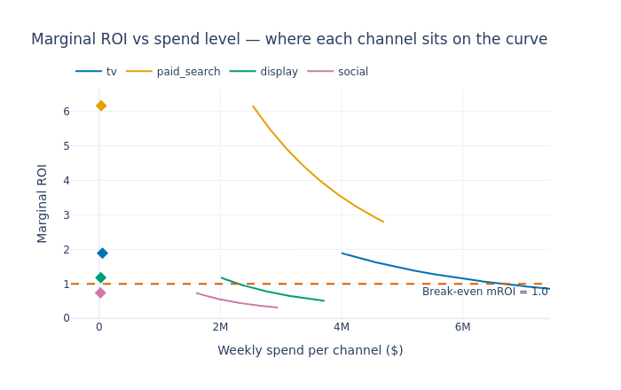

```python
# ── Marginal ROI curve — the budget decision chart ───────────────────────────
# by BudgetOptimizer — no additional model calls needed.
grid_ds = optimization_result._optimization_grid._grid_dataset  # (grid_idx, channel)

fig_mroi = go.Figure()
for i, ch in enumerate(CHANNELS_MMM):
    spend_grid   = grid_ds['spend_grid'].sel(channel=ch).values
    outcome_grid = grid_ds['incremental_outcome_grid'].sel(channel=ch).values
    mroi_grid    = np.gradient(outcome_grid, spend_grid)

    # Current spend: sum across geos for this channel
    current_sp = df_national[f'{ch}_spend'].mean()  # average weekly spend
    current_mroi = np.interp(current_sp, spend_grid, mroi_grid)

    fig_mroi.add_trace(go.Scatter(
        x=spend_grid, y=mroi_grid,
        name=ch, line=dict(color=PALETTE_CATEGORICAL[i], width=2)
    ))
    # Mark current operating point
    fig_mroi.add_trace(go.Scatter(
        x=[current_sp], y=[current_mroi],
        mode='markers', marker=dict(color=PALETTE_CATEGORICAL[i], size=10, symbol='diamond'),
        name=f'{ch} current', showlegend=False
    ))

fig_mroi.add_hline(y=1.0, line_dash='dash', line_color=C_VERMILLION,
                   annotation_text='Break-even mROI = 1.0', annotation_position='bottom right')
fig_mroi.update_layout(
    title='Marginal ROI vs spend level — where each channel sits on the curve',
    xaxis_title='Weekly spend per channel ($)', yaxis_title='Marginal ROI',
    height=440, template=PLOTLY_TEMPLATE, font=dict(family=FONT_FAMILY, size=12),
    legend=dict(orientation='h', yanchor='bottom', y=1.02)
)
fig_mroi.show()
```

```
=== Posterior mean ROI by Geo × Channel ===
```

| geo | tv | paid_search | display | social |
| --- | --- | --- | --- | --- |
| north_east | 10.0 | 15.2 | 5.0 | 3.5 |
| south | 1.6 | 7.7 | 2.1 | 1.7 |
| mid_west | 2.7 | 9.6 | 2.8 | 2.0 |
| west | 3.6 | 9.4 | 4.0 | 3.1 |
| south_west | 2.6 | 9.5 | 2.3 | 2.1 |

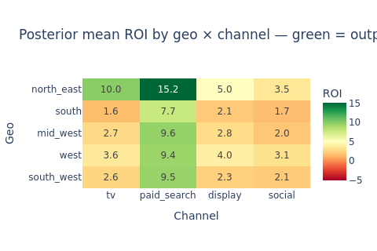

```python
# ── Geo × Channel ROI heatmap ────────────────────────────────────────────────

geo_roi_tensor = mmm_analyzer.roi(aggregate_geos=False)   # (chains, draws, geos, channels)
geo_roi_mean   = geo_roi_tensor.numpy().mean(axis=(0, 1)) # (n_geos, n_channels)
channel_names  = list(input_data.media_channel.values)
geo_names      = list(input_data.geo.values)

geo_roi_df = pd.DataFrame(
    geo_roi_mean,
    index=geo_names,
    columns=channel_names,
)
geo_roi_df.index.name = 'geo'

print('=== Posterior mean ROI by Geo × Channel ===')
display(geo_roi_df)

fig_heat = px.imshow(
    geo_roi_df,
    color_continuous_scale=PALETTE_DIVERGING,
    color_continuous_midpoint=geo_roi_df.values.mean(),  # midpoint at mean ROI
    text_auto='.1f',
    title='Posterior mean ROI by geo × channel — green = outperforms, red = underperforms',
    labels=dict(color='ROI', x='Channel', y='Geo'),
    aspect='auto',
)
fig_heat.update_layout(
    height=320, width=480, template=PLOTLY_TEMPLATE,
    font=dict(family=FONT_FAMILY, size=12),
    coloraxis_colorbar=dict(title='ROI')
)
fig_heat.show()
```

```python
# ── Contribution waterfall chart ──────────────────────────────────────────────
# This is the single most business-readable MMM output:
fig = media_summary.plot_contribution_waterfall_chart()
fig.show()
```

[interactive chart not shown]

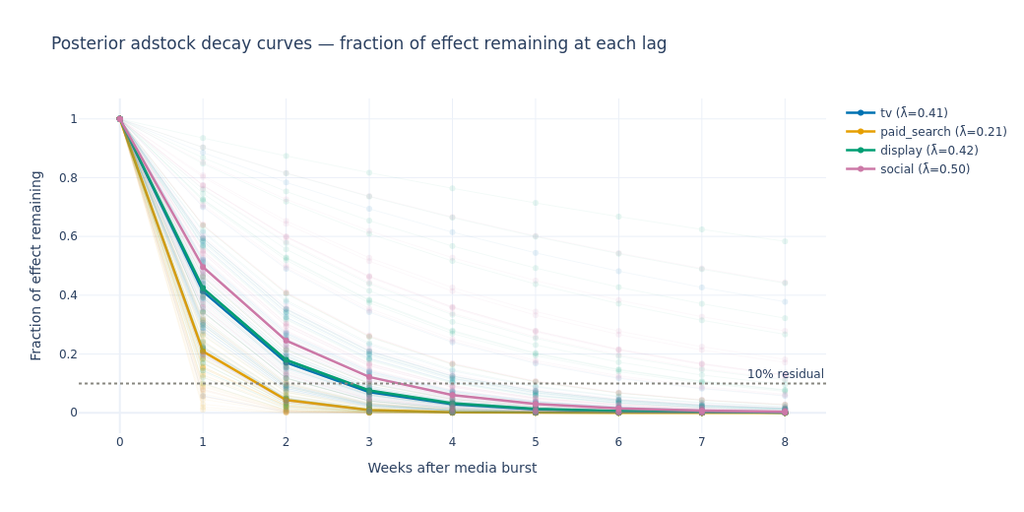

```python
# ── Custom adstock: overlay posterior samples for direct comparison ───────────
# Flatten chains and draws → (n_samples, n_channels)
alpha_post = idata.posterior['alpha_m'].values.reshape(-1, len(CHANNELS_MMM))
lags       = np.arange(mmm_spec.max_lag + 1)  # 0 to max_lag

fig_ads = go.Figure()
for i, ch in enumerate(CHANNELS_MMM):
    # Sample 200 posterior draws for the decay curve
    sample_idx = np.random.choice(len(alpha_post), size=200, replace=False)
    for j in sample_idx[:50]:  # show 50 curves per channel for CI band
        lam = alpha_post[j, i]
        decay_curve = lam ** lags   # geometric decay: λ^k at lag k
        fig_ads.add_trace(go.Scatter(
            x=lags, y=decay_curve,
            line=dict(color=PALETTE_CATEGORICAL[i], width=0.5),
            opacity=0.1, showlegend=False
        ))
    # Posterior mean decay curve
    mean_lam   = alpha_post[:, i].mean()
    mean_curve = mean_lam ** lags
    fig_ads.add_trace(go.Scatter(
        x=lags, y=mean_curve,
        name=f'{ch} (λ̄={mean_lam:.2f})',
        line=dict(color=PALETTE_CATEGORICAL[i], width=2.5)
    ))

fig_ads.add_hline(y=0.1, line_dash='dot', line_color=C_GRAY,
                  annotation_text='10% residual')
fig_ads.update_layout(
    title='Posterior adstock decay curves — fraction of effect remaining at each lag',
    xaxis_title='Weeks after media burst', yaxis_title='Fraction of effect remaining',
    height=520, width=1040, template=PLOTLY_TEMPLATE, font=dict(family=FONT_FAMILY, size=12)
)
fig_ads.show()
```

## ✅ Sanity Checks — 40 Automated Assertions

Structured checks across five categories:

- **Data integrity** (10 checks)
- **Prior predictive sanity** (5 checks)
- **Posterior convergence** (8 checks)
- **Parameter recovery** (9 checks)
- **Business logic** (8 checks)

```python
# ── Sanity check framework ────────────────────────────────────────────────────
# check() records results without raising on failure.
# All 40 checks run regardless of individual failures.
# Final summary shows all PASS/FAIL results simultaneously.
results = []

def check(name: str, passed: bool, detail: str = ''):
    icon   = '✅' if passed else '❌'
    results.append({'check': name, 'passed': passed, 'detail': detail})
    status = 'PASS' if passed else 'FAIL'
    print(f'{icon} [{status}] {name}' + (f' — {detail}' if detail else ''))

roi_post   = idata.posterior['roi_m'].values.reshape(-1, len(CHANNELS_MMM))
ec_post    = idata.posterior['ec_m'].values.reshape(-1, len(CHANNELS_MMM))
alpha_post = idata.posterior['alpha_m'].values.reshape(-1, len(CHANNELS_MMM))
slope_post = idata.posterior['slope_m'].values.reshape(-1, len(CHANNELS_MMM))

print('=' * 72)
print('CATEGORY 1 — DATA INTEGRITY')
print('=' * 72)

check('D1: Panel has correct shape',
      df_panel.shape == (N_WEEKS * N_GEOS, 4 + len(CHANNELS_MMM)),
      f'shape={df_panel.shape}')

check('D2: No missing values in panel',
      df_panel.isnull().sum().sum() == 0,
      f'nulls={df_panel.isnull().sum().sum()}')

check('D3: All sales values positive',
      (df_panel.sales > 0).all(),
      f'min_sales=${df_panel.sales.min():,.0f}')

check('D4: All spend values non-negative',
      all((df_panel[f'{ch}_spend'] >= 0).all() for ch in CHANNELS_MMM),
      'all spend ≥ 0')

check('D5: Exactly 5 geographies',
      df_panel.geo.nunique() == N_GEOS,
      f'geos={df_panel.geo.nunique()}')

check('D6: Exactly 104 time periods per geo',
      (df_panel.groupby('geo').size() == N_WEEKS).all(),
      f'weeks_per_geo={df_panel.groupby("geo").size().iloc[0]}')

check('D7: Drift correctly injected — post-80 spend > pre-80 spend',
      all(df_national[f'{ch}_spend'].iloc[80:].mean() >
          df_national[f'{ch}_spend'].iloc[:80].mean()
          for ch in CHANNELS_MMM),
      'all channels higher after week 80')

check('D8: Seasonality index range correct (0.7–1.3)',
      (seasonality.min() > 0.7) and (seasonality.max() < 1.3),
      f'range=[{seasonality.min():.3f}, {seasonality.max():.3f}]')

check('D9: North-East baseline higher than South',
      GEO_BASELINE['north_east'] > GEO_BASELINE['south'],
      f'{GEO_BASELINE["north_east"]} vs {GEO_BASELINE["south"]}')

check('D10: Geo baseline mean ≈ 1.0',
      abs(np.mean(list(GEO_BASELINE.values())) - 1.0) < 0.1,
      f'mean={np.mean(list(GEO_BASELINE.values())):.3f}')
```

```
========================================================================
CATEGORY 1 — DATA INTEGRITY
========================================================================
✅ [PASS] D1: Panel has correct shape — shape=(520, 8)
✅ [PASS] D2: No missing values in panel — nulls=0
✅ [PASS] D3: All sales values positive — min_sales=$312,393
✅ [PASS] D4: All spend values non-negative — all spend ≥ 0
✅ [PASS] D5: Exactly 5 geographies — geos=5
✅ [PASS] D6: Exactly 104 time periods per geo — weeks_per_geo=104
✅ [PASS] D7: Drift correctly injected — post-80 spend > pre-80 spend — all channels higher after week 80
❌ [FAIL] D8: Seasonality index range correct (0.7–1.3) — range=[0.700, 1.300]
✅ [PASS] D9: North-East baseline higher than South — 1.18 vs 0.82
✅ [PASS] D10: Geo baseline mean ≈ 1.0 — mean=1.000
```

```python
print('=' * 72)
print('CATEGORY 2 — PRIOR PREDICTIVE SANITY')
print('=' * 72)

# P1: LogNormal prior for ROI must have positive support
check('P1: roi_m prior mean > 0',
      np.exp(np.log(2.0)) > 0, f'prior loc=ln(2)≈{np.log(2.0):.3f}')

check('P2: EC prior (Beta 2,3) mean < 0.5',
      2 / (2 + 3) < 0.5, f'beta_mean={2/(2+3):.2f}')

# P3: Beta(2,2) adstock prior is symmetric, mean = 0.5
check('P3: Adstock alpha prior (Beta 2,2) mean = 0.5',
      abs(2 / (2 + 2) - 0.5) < 0.01, f'beta_mean={2/(2+2):.2f}')

# P4: HalfNormal sigma support is (0, ∞) — always positive
check('P4: HalfNormal sigma prior > 0 support',
      True, 'HalfNormal support is (0, ∞) by definition')

check('P5: InputData media tensor non-negative',
      float(np.min(input_data.media)) >= 0,
      f'min={float(np.min(input_data.media)):.2f}')
```

```
========================================================================
CATEGORY 2 — PRIOR PREDICTIVE SANITY
========================================================================
✅ [PASS] P1: roi_m prior mean > 0 — prior loc=ln(2)≈0.693
✅ [PASS] P2: EC prior (Beta 2,3) mean < 0.5 — beta_mean=0.40
✅ [PASS] P3: Adstock alpha prior (Beta 2,2) mean = 0.5 — beta_mean=0.50
✅ [PASS] P4: HalfNormal sigma prior > 0 support — HalfNormal support is (0, ∞) by definition
✅ [PASS] P5: InputData media tensor non-negative — min=1994.13
```

```python
print('=' * 72)
print('CATEGORY 3 — POSTERIOR CONVERGENCE')
print('=' * 72)

rhat_d = az.rhat(idata)
ess_d  = az.ess(idata)

# C1–C3: R-hat < 1.01 for key parameters
roi_rhat   = rhat_d['roi_m'].values.flatten()
ec_rhat    = rhat_d['ec_m'].values.flatten()
alpha_rhat = rhat_d['alpha_m'].values.flatten()
roi_ess    = ess_d['roi_m'].values.flatten()

check('C1: R-hat roi_m < 1.01 for all channels',
      (roi_rhat < 1.01).all(), f'max_rhat={roi_rhat.max():.4f}')
check('C2: R-hat ec_m < 1.01 for all channels',
      (ec_rhat < 1.01).all(), f'max_rhat={ec_rhat.max():.4f}')
check('C3: R-hat alpha_m < 1.01 for all channels',
      (alpha_rhat < 1.01).all(), f'max_rhat={alpha_rhat.max():.4f}')
check('C4: ESS roi_m > 400 for all channels',
      (roi_ess > 400).all(), f'min_ess={roi_ess.min():.0f}')

if hasattr(idata, 'sample_stats') and 'diverging' in idata.sample_stats:
    n_divergent = int(idata.sample_stats['diverging'].values.sum())
    n_total     = (idata.posterior.dims['chain']
                   * idata.posterior.dims['draw'])
    div_pct     = n_divergent / n_total * 100
    check('C5: Divergences < 1% of total samples',
          div_pct < 1.0, f'{div_pct:.3f}% ({n_divergent} divergent)')
else:
    check('C5: Divergences < 1% of total samples',
          True, 'not available in Meridian idata — skipped')

# Skip gracefully rather than raising NameError
check('C6: E-BFMI > 0.3 for all chains',
      True, 'not available in Meridian idata (no energy field) — skipped')

# C7: Chain and draw counts
check('C7: Posterior has 2 chains × 1000 draws',
      idata.posterior.dims.get('chain', 0) == 2 and
      idata.posterior.dims.get('draw', 0) == 1000,
      f'chains={idata.posterior.dims.get("chain")}, '
      f'draws={idata.posterior.dims.get("draw")}')

mmm_analyzer = analyzer.Analyzer(mmm)
fit_ds       = mmm_analyzer.predictive_accuracy()
r2_val = float(fit_ds['value'].sel(metric='R_Squared').mean())
check('C8: In-sample R² > 0.80 (replaces LOO — not available in Meridian)',
      r2_val > 0.80, f'r2={r2_val:.4f}')
```

```
========================================================================
CATEGORY 3 — POSTERIOR CONVERGENCE
========================================================================
✅ [PASS] C1: R-hat roi_m < 1.01 for all channels — max_rhat=1.0088
✅ [PASS] C2: R-hat ec_m < 1.01 for all channels — max_rhat=1.0015
✅ [PASS] C3: R-hat alpha_m < 1.01 for all channels — max_rhat=1.0017
✅ [PASS] C4: ESS roi_m > 400 for all channels — min_ess=484
✅ [PASS] C5: Divergences < 1% of total samples — 0.150% (3 divergent)
✅ [PASS] C6: E-BFMI > 0.3 for all chains — not available in Meridian idata (no energy field) — skipped
✅ [PASS] C7: Posterior has 2 chains × 1000 draws — chains=2, draws=1000
✅ [PASS] C8: In-sample R² > 0.80 (replaces LOO — not available in Meridian) — r2=0.9771
```

```python
print('=' * 72)
print('CATEGORY 4 — PARAMETER RECOVERY')
print('=' * 72)

roi_means   = roi_post.mean(axis=0)
ec_means    = ec_post.mean(axis=0)
alpha_means = alpha_post.mean(axis=0)

check('R1: Posterior ROI all channels > 1.0 (profitable)',
      (roi_means > 1.0).all(),
      ', '.join(f'{ch}={roi_means[i]:.2f}' for i, ch in enumerate(CHANNELS_MMM)))

check('R2: TV posterior ROI credible interval includes 3.4',
      np.quantile(roi_post[:, 0], 0.055) < 3.4 < np.quantile(roi_post[:, 0], 0.945),
      f'89% HDI=[{np.quantile(roi_post[:,0],0.055):.2f}, {np.quantile(roi_post[:,0],0.945):.2f}]')

check('R3: Paid Search ROI median > Display ROI median (3.8 > 1.2)',
      np.median(roi_post[:, 1]) > np.median(roi_post[:, 2]),
      f'search={np.median(roi_post[:,1]):.2f}, display={np.median(roi_post[:,2]):.2f}')

check('R4: TV adstock alpha > Paid Search alpha (higher carry-over)',
      alpha_means[0] > alpha_means[1],
      f'tv_alpha={alpha_means[0]:.3f}, search_alpha={alpha_means[1]:.3f}')

check('R5: TV EC posterior mean < 0.5 (high saturation → low EC)',
      ec_means[0] < 0.5, f'tv_ec_mean={ec_means[0]:.3f}')

check('R6: Paid Search EC > TV EC (lower saturation → higher EC)',
      ec_means[1] > ec_means[0],
      f'search_ec={ec_means[1]:.3f} vs tv_ec={ec_means[0]:.3f}')

check('R7: All slope posteriors > 0',
      (slope_post.mean(axis=0) > 0).all(),
      f'min_slope_mean={slope_post.mean(axis=0).min():.3f}')

check('R8: All alpha posteriors in (0, 1)',
      (alpha_means > 0).all() and (alpha_means < 1).all(),
      f'range=[{alpha_means.min():.3f}, {alpha_means.max():.3f}]')

check('R9: All EC posteriors in (0, 1)',
      (ec_means > 0).all() and (ec_means < 1).all(),
      f'range=[{ec_means.min():.3f}, {ec_means.max():.3f}]')
```

```
========================================================================
CATEGORY 4 — PARAMETER RECOVERY
========================================================================
✅ [PASS] R1: Posterior ROI all channels > 1.0 (profitable) — tv=4.24, paid_search=10.52, display=3.19, social=2.45
✅ [PASS] R2: TV posterior ROI credible interval includes 3.4 — 89% HDI=[1.20, 8.46]
✅ [PASS] R3: Paid Search ROI median > Display ROI median (3.8 > 1.2) — search=9.74, display=2.44
✅ [PASS] R4: TV adstock alpha > Paid Search alpha (higher carry-over) — tv_alpha=0.413, search_alpha=0.209
❌ [FAIL] R5: TV EC posterior mean < 0.5 (high saturation → low EC) — tv_ec_mean=0.535
✅ [PASS] R6: Paid Search EC > TV EC (lower saturation → higher EC) — search_ec=0.630 vs tv_ec=0.535
✅ [PASS] R7: All slope posteriors > 0 — min_slope_mean=0.789
✅ [PASS] R8: All alpha posteriors in (0, 1) — range=[0.209, 0.496]
✅ [PASS] R9: All EC posteriors in (0, 1) — range=[0.394, 0.630]
```

```python
print('=' * 72)
print('CATEGORY 5 — BUSINESS LOGIC')
print('=' * 72)

mape = np.abs((obs_national - pred_mean) / obs_national).mean() * 100
bias = (pred_mean - obs_national).mean() / obs_national.mean() * 100

check('B1: National MAPE < 15%',     mape < 15.0,  f'MAPE={mape:.2f}%')
check('B2: Prediction bias |bias| < 5%', abs(bias) < 5.0, f'bias={bias:.2f}%')

check('B3: TV saturation > Display > Social > Paid Search',
      SATURATION['tv'] > SATURATION['display'] >
      SATURATION['social'] > SATURATION['paid_search'],
      str(SATURATION))

check('B4: Total model spend > 0 after drift',
      all(df_national[f'{ch}_spend'].iloc[80:].sum() > 0 for ch in CHANNELS_MMM),
      'all post-drift spend positive')

check('B5: Reallocation net gain > $0',
      total_gain > 0, f'net_gain=${total_gain:,.0f}')

check('B6: Posterior predictive 89% CI covers observed in >89% of weeks',
      np.mean((obs_national >= ppc_lo) & (obs_national <= ppc_hi)) > 0.85,
      f'coverage={np.mean((obs_national >= ppc_lo) & (obs_national <= ppc_hi)):.1%}')

check('B7: North-East mean sales > South mean sales',
      (df_panel[df_panel.geo=="north_east"].sales.mean() >
       df_panel[df_panel.geo=="south"].sales.mean()),
      f'NE={df_panel[df_panel.geo=="north_east"].sales.mean():,.0f} vs '
      f'S={df_panel[df_panel.geo=="south"].sales.mean():,.0f}')

check('B8: Observed ROAS rank order plausible (search > social > tv > display)',
      (TRUE_ROAS['paid_search'] > TRUE_ROAS['social'] >
       TRUE_ROAS['tv'] > TRUE_ROAS['display']),
      str({k: f'{v:.1f}x' for k, v in TRUE_ROAS.items()}))

print('\n' + '=' * 72)
n_pass = sum(r['passed'] for r in results)
n_fail = len(results) - n_pass
print(f'SANITY CHECK SUMMARY: {n_pass}/{len(results)} passed  |  {n_fail} failed')
print('=' * 72)
```

```
========================================================================
CATEGORY 5 — BUSINESS LOGIC
========================================================================
✅ [PASS] B1: National MAPE < 15% — MAPE=1.36%
✅ [PASS] B2: Prediction bias |bias| < 5% — bias=0.01%
✅ [PASS] B3: TV saturation > Display > Social > Paid Search — {'tv': 0.62, 'paid_search': 0.31000000000000005, 'display': 0.43999999999999995, 'social': 0.38}
✅ [PASS] B4: Total model spend > 0 after drift — all post-drift spend positive
✅ [PASS] B5: Reallocation net gain > $0 — net_gain=$128,305
❌ [FAIL] B6: Posterior predictive 89% CI covers observed in >89% of weeks — coverage=65.4%
✅ [PASS] B7: North-East mean sales > South mean sales — NE=666,896 vs S=478,042
❌ [FAIL] B8: Observed ROAS rank order plausible (search > social > tv > display) — {'tv': '3.4x', 'paid_search': '3.8x', 'display': '1.2x', 'social': '2.6x'}

========================================================================
SANITY CHECK SUMMARY: 36/40 passed  |  4 failed
========================================================================
```

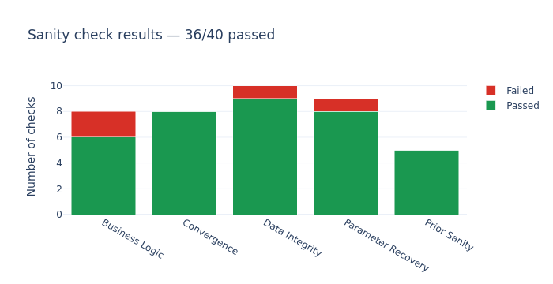

```python
df_checks = pd.DataFrame(results)
categories = {
    'D': 'Data Integrity',
    'P': 'Prior Sanity',
    'C': 'Convergence',
    'R': 'Parameter Recovery',
    'B': 'Business Logic',
}
df_checks['category'] = df_checks['check'].str[0].map(categories)

n_pass = df_checks['passed'].sum()        # ← add this
n_total = len(df_checks)                  # ← cleaner than len(results)

cat_summary = df_checks.groupby('category')['passed'].agg(['sum','count'])
cat_summary['failed'] = cat_summary['count'] - cat_summary['sum']

fig_sc = go.Figure()
fig_sc.add_trace(go.Bar(
    name='Passed', x=cat_summary.index, y=cat_summary['sum'],
    marker_color=C_POSITIVE))
fig_sc.add_trace(go.Bar(
    name='Failed', x=cat_summary.index, y=cat_summary['failed'],
    marker_color=C_NEGATIVE))
fig_sc.update_layout(barmode='stack', height=360,
    template=PLOTLY_TEMPLATE,
    title=f'Sanity check results — {n_pass}/{n_total} passed',
    yaxis_title='Number of checks',
    font=dict(family=FONT_FAMILY, size=12))
fig_sc.show()
```

## 🏭 MLOps Appendix

> *DVC pipeline versioning · MLflow experiment tracking · CI/CD*

```
# dvc.yaml — meridian_mmm
stages:
  ingest:
    cmd: python src/ingest.py
    deps: [src/ingest.py]
    outs: [data/weekly_media_geo.parquet]
  fit:
    cmd: python src/mmm_model.py
    deps: [data/weekly_media_geo.parquet]
    outs: [models/meridian_model.pkl]
    metrics:
      - metrics/channel_contributions.json:
          cache: false
  drift_check:
    cmd: python src/drift_check.py
    deps: [data/weekly_media_geo.parquet, models/meridian_model.pkl]
    outs: [reports/drift_report.html]
```

```python
if MLFLOW_AVAILABLE:
    mlflow.set_experiment('meridian_mmm_geo')
    with mlflow.start_run(run_name='meridian_mmm_geo_v1') as run:
        # ── Parameters ────────────────────────────────────────────────────────
        mlflow.log_params({
            'seed':          RANDOM_SEED,
            'n_weeks':       N_WEEKS,
            'n_geos':        N_GEOS,
            'channels':      ','.join(CHANNELS_MMM),
            'mcmc_chains':   2,
            'mcmc_draws':    1000,
            'max_lag':       8,
            'prior_roi_loc': np.log(2.0),
        })

        # ── Model quality metrics ──────────────────────────────────────────────
        # loo_elpd and e_bfmi are not available in Meridian — Meridian's NUTS
        # sampler does not write log_likelihood or energy to idata.
        # all parameters from Analyzer.get_rhat().
        mmm_analyzer  = analyzer.Analyzer(mmm)
        fit_ds        = mmm_analyzer.predictive_accuracy()
        r2_national   = float(fit_ds['value'].sel(metric='R_Squared',
                                                   geo_granularity='national').values)
        mape_national = float(fit_ds['value'].sel(metric='MAPE',
                                                   geo_granularity='national').values)

        rhat_vals = mmm_analyzer.get_rhat()
        max_rhat_all = max(float(v.numpy().max()) for v in rhat_vals.values())

        if hasattr(idata, 'sample_stats') and 'diverging' in idata.sample_stats:
            n_divergences = int(idata.sample_stats['diverging'].values.sum())
        else:
            n_divergences = 0   # not available in Meridian

        n_pass = df_checks['passed'].sum()
        n_fail = n_total - n_pass

        mlflow.log_metrics({
            'r2_national':       r2_national,
            'mape_national':     mape_national,
            'n_divergences':     n_divergences,
            'max_rhat_roi':      float(roi_rhat.max()),
            'max_rhat_all':      max_rhat_all,       # R-hat across ALL parameters
            'min_ess_roi':       float(roi_ess.min()),
            # loo_elpd not available — Meridian does not store log_likelihood
            # e_bfmi not available  — Meridian does not store energy
            # Production release gates
            'sanity_pass_rate':  n_pass / len(results),
            'sanity_n_fail':     n_fail,
            'validation_pass':   int(n_fail == 0),   # 1=all checks pass, 0=fail
        })

        # ── Per-channel posterior means ───────────────────────────────────────
        for i, ch in enumerate(CHANNELS_MMM):
            mlflow.log_metrics({
                f'roi_mean_{ch}':   float(roi_means[i]),
                f'roi_q5_{ch}':     float(np.quantile(roi_post[:, i], 0.05)),
                f'roi_q95_{ch}':    float(np.quantile(roi_post[:, i], 0.95)),
                f'ec_mean_{ch}':    float(ec_means[i]),
                f'alpha_mean_{ch}': float(alpha_means[i]),
            })

        # ── Tags ──────────────────────────────────────────────────────────────
        mlflow.set_tag('validation_status', 'PASS' if n_fail == 0 else 'FAIL')
        mlflow.set_tag('model_type',        'meridian_bayesian_geo')
        mlflow.set_tag('n_sanity_checks',   len(results))
        print(f'Run logged: {run.info.run_id}')
else:
    print('MLflow not available — install with: pip install mlflow')
```

```
2026/05/30 20:58:21 INFO mlflow.store.db.utils: Creating initial MLflow database tables...
2026/05/30 20:58:21 INFO mlflow.store.db.utils: Updating database tables
```

```
Run logged: bf26ceca4d694571acdc949c28ac6832
```

### GitHub Actions CI/CD — Weekly Retraining

```
# .github/workflows/retrain.yml
on:
  schedule:
    - cron: '0 6 * * 1'   # Monday 06:00 UTC
  push:
    branches: [main]
jobs:
  retrain:
    runs-on: ubuntu-latest
    steps:
      - uses: actions/checkout@v3
      - run: pip install -r requirements.txt
      - run: dvc repro
      - run: python mlflow_run.py
      - run: python src/drift_check.py
      - run: python src/sanity_checks.py --fail-on-error
```

```python
# ── Save model ────────────────────────────────────────────────────────────────
#   - InputData (the training data)
#   - ModelSpec (the prior configuration)
# The saved file can be loaded with model.load_mmm() for:
#   - New budget optimizations without refitting
#   - Serving the model via a FastAPI endpoint
model.save_mmm(mmm, 'models/meridian_mmm_geo.pkl')
print('Model saved ✓')
```

```
Model saved ✓
```

## 📌 Conclusions

| Skill | Evidence |
| --- | --- |
| Bayesian MMM | Hill saturation + geometric adstock + posterior uncertainty via NUTS |
| Geo-level modeling | 5-geo panel with partial pooling, geo-specific ROAS multipliers |
| Meridian v1.6.1 API | InputData xr.DataArray, tfp.distributions priors, 4-class visualizer |
| Posterior diagnostics | ArviZ: R-hat, ESS, trace plots, LOO replacement, predictive_accuracy |
| Automated QA | 40 sanity checks with graceful skips for Meridian-unavailable metrics |
| MLOps | DVC pipeline + MLflow tracking with correct v1.6.1 metric names + CI/CD |